# Dobutamine Stress Echocardiography and the Prediction of Cardiac Events

## 0.1 An Important Note Regarding this Example

This example was mostly built in Spring 2017, and the code here has largely **NOT** been updated to reflect changes in the way I am teaching 432 this year. In particular, I expect that people writing their project in 2018 will probably:

1. use simple imputation rather than complete case analyses when there are missing data
2. use a multiple imputation approach other than the ones presented here, or focus only on simple imputation
3. cross-validate more frequently, and in different ways than are presented here
4. use `lm` and `glm` methods more frequently than is shown here
5. use `ols` and `lrm` methods less frequently than is shown here
6. use `ggplot2` approaches to build plots in all cases
7. make better use of some of the tools from the `tidyverse`, especially `forcats` to deal with factors.
8. choose to include some of the materials represented here, but not all.

## 0.2 Preliminaries

```r
library(knitr); library(rmdformats)

## Global options
opts_chunk$set(comment = NA,
               warning = FALSE,
               message = FALSE)
#opts_knit$set(width=75)
```

```r
library(arm)
library(leaps)
library(tableone)
library(pander)
library(ROCR)
library(skimr)
library(rms)
library(broom)
library(tidyverse)
```

Be sure to add any additional packages you want to use, and leave the `tidyverse` last.

# 1 Task 1: Data Source

These data come from a study done at UCLA, and provided by Alan Garfinkel, Ph.D. at UCLA’s Department of Physiology. The results of the initial study were published in Krivokapich J Child JS Walter DO Garfinkel A “Prognostic Value of Dobutamine Stress Echocardiography in Predicting Cardiac Events in Patients With Known or Suspected Coronary Artery Disease.” *Journal of the American College of Cardiology* 33.3 (1999) 708-16. That article [may be found here](http://www.onlinejacc.org/content/33/3/708), and a PDF is provided at our web site.

A fairly complete [explanation of the study](http://www.stat.ucla.edu/projects/datasets/cardiac-explanation.html) is available online, including a link to the raw data, called `cardiac.dat`. A related data set (called `stressEcho`) is also available at [the Vanderbilt Biostatistics wiki](http://biostat.mc.vanderbilt.edu/wiki/pub/Main/DataSets/CstressEcho.html), and another is at [the OER Commons](http://www.oercommons.org/courses/garfinkel-cardiac-data/view) but we will use the raw data from UCLA, instead.

The data in the `cardiac.dat` file describe 220 men and 338 women who underwent dobutamine stress echocardiography, and then were followed for 12 months, and this comprises the complete sample of patients included in the study. Despite its `.dat` filename extension, the `cardiac.dat` is comma-delimited, and can be read into a tibble with the `read_csv` function.

## 1.1 Explanation of the Study from UCLA

Excerpted from: http://www.stat.ucla.edu/projects/datasets/cardiac-explanation.html

This data is from a study that was trying to determine if a drug called “dobutamine” could be used effectively in a test for measuring a patient’s risk of having a heart attack, or “cardiac event.”

For younger patients, a typical test of this risk is called “Stress Echocardiography.” It involves raising the patient’s heart rate by exercise - often by having the patient run on a treadmill - and then taking various measurements, such as heart rate and blood pressure, as well as more complicated measurements of the heart.

The problem with this test is that it often cannot be used on older patients whose bodies can’t take the stress of hard exercise. The key to assessing risk, however, is putting stress on the heart before taking the relevant measurements. While exercise can’t be used to create this stress for older patients, the drug dobutamine can.

This study, then, was partly an attempt to see if the stress echocardiography test was still effective in predicting cardiac events when the stress on the heart was produced by dobutamine instead of exercise. More specifically, though, the study sought to pinpoint which measurements taken during the stress echocardiography test were most helpful in predicting whether or not a patient suffered a cardiac event over the next year.

# 2 Task 2: Load and Tidy the Data

## 2.1 Data Load

```r
card0 <- read.csv("cardiac.dat") %>% tbl_df()
```

As originally loaded, the `card0` data contain 558 rows and 42 columns. Explanations of each of the original variables in the `cardiac.dat` set is found at http://www.stat.ucla.edu/projects/datasets/cardiac-explanation.html

## 2.2 Tidying, Data Cleaning and Data Management

There are several things going on in the next bit of code, which maintains the original as-imported data as `card0` but creates a new tibble called `stressEcho`.

```r
stressEcho <- card0 %>%
    rename(female = gender) %>%
    mutate(patient = 1:nrow(card0),
           chestpain_c = as.factor(1 - chestpain),
           SE_res = 1 - posSE,
           SE_res = factor(SE_res,
                           levels = c(0, 1),
                           labels = c("Negative", "Positive")),
           hx_smoking = as.factor(ifelse(hxofcig < 1, "smoker", "non-smoker")),
           event = ifelse(death + newMI + newPTCA + newCABG < 4,
                          1, 0),
           ecg = ifelse(posECG == 0, "MI",
                        ifelse(equivecg == 0,
                               "Equivocal", "Normal")),
           ecg = fct_relevel(ecg, "Normal")) %>%
    select(patient, age, female, bhr, basebp, baseEF, dose,
           hx_smoking, chestpain_c, ecg, SE_res, dobEF, event)
```

The remainder of this section describes the changes made in the code above.

### 2.2.1 Rename `gender` to `female` to represent the patient’s sex

Relevant code:

```
    rename(female = gender)
```

The `gender` variable in this case doesn’t represent the social construct of `gender` but rather a biological status, better identified as `sex`. In addition, the codes used are hidden from the data frame when they don’t need to be.

The definition of `gender` in this data set is:

- `gender` = 1 if the patient’s sex is female, and
- `gender` 0 if the patient’s sex is male.

If the data were presented as “Male” or “Female” or something similar, we might just rename the `gender` variable as `sex` and move on. But since the data are numeric (1/0) we will rename this more usefully as `female` which takes the same values as the original `gender`. `female` is then a standard indicator variable, with

- `female` = 1 if the patient’s sex is female, and
- `female` 0 if the patient’s sex is male.

If we wanted to, we could certainly choose to treat `female` as a factor, as we have done with other variables here, but we won’t, so you can see what happens when we tabulate or model.

#### 2.2.1.1 Sanity Check

The old `gender` and new `female` variables should have identical values, showing 220 male and 338 female patients.

```r
table(card0$gender, stressEcho$female)
```

```
      0   1
  0 220   0
  1   0 338
```

#### 2.2.1.2 A Note on the `any event` variable

One of the variable names (`any event`) imported by `read_csv` includes a space. That`any event` variable needs to be placed in backwards single quotes in order to be recognized as a variable, which will be problematic in models, so if we were going to use that variable we would change its name, as well, to `any_event`. As it turns out, we’re not going to use the `any_event` variable, so `any_event` and `any event` are left out of `stressEcho`.

### 2.2.2 Add patient Numbers

Relevant code:

```
    mutate(patient = 1:nrow(card0))
```

In this data set, we have no variable identifying the patients. We’ll create one, called `patient`, using consecutive integers, and store it as an *integer*, rather than as a character, as I had suggested in the past.

#### 2.2.2.1 Sanity Check

```r
glimpse(stressEcho$patient)
```

```
 int [1:558] 1 2 3 4 5 6 7 8 9 10 ...
```

### 2.2.3 Reverse Binary Numeric Coding for `chestpain` and `posSE`, then create factors

Relevant code:

```
    mutate(SE_res = 1 - posSE,
           SE_res = factor(SE_res,
                           levels = c(0, 1),
                           labels = c("Negative", "Positive")))
```

The binary numeric variables we will use include `chestpain` and `posSE`. Contrary to statistical convention, the `cardiac.dat` file uses this approach:

- `chestpain = 1` means that the patient DID NOT suffer chest pain, and
- `chestpain = 0` means that the patient DID suffer chest pain.

That’ll drive us (well, at least me) crazy, so we’ll create a new variable, called `chestpain_c` that corrects this so that:

- `chestpain_c = 1` means the patient did suffer chest pain, and
- `chestpain_c = 0` means the patient did not suffer chest pain.

And we’ll do the same thing to create `SE_res` which describes whether a stress echocardiogram was positive, based on the values of `posSE` in the original data. So

- `posSE` = 0 means a positive stress echo, so we want `SE_res` to be 1, which we’ll label as “Positive”
- `posSE` = 1 means a negative stress echo, so we want `SE_res` to be 0, which we’ll label as “Negative”

A nice trick is that we can change numeric results from 0/1 to 1/0 by simply subtracting each value from 1.

Here, we’ll use the convention `_c` to indicate a *corrected* version of the original `chestpain` variable that still uses numbers, but we’ll specify actual names (Negative and Positive) for the labels in the `SE_res` variable as a factor. Either approach is fine, practically.

#### 2.2.3.1 Sanity Check

The `chestpain_c` results in `stressEcho` should be the opposite (0 becomes 1, and 1 becomes 0) of the original `chestpain` variable from `card0`.

```r
table(card0$chestpain, stressEcho$chestpain_c)
```

```
      0   1
  0   0 172
  1 386   0
```

The positive `SE_res` should be associated with the initial `posSE` = 0.

```r
table(card0$posSE, stressEcho$SE_res)
```

```
    Negative Positive
  0        0      136
  1      422        0
```

### 2.2.4 Create a Binary Factor from a Strangely-Coded Three-Level Variable on Smoking History

Relevant code:

```
    mutate(hx_smoking = as.factor(ifelse(hxofcig < 1, "smoker", "non-smoker")))
```

Create a `hx_smoking` variable, which is defined on the basis of the `hxofcig` variable in the original data set (that uses strange 0 = current smoker, 0.5 = former smoker, 1 = never a smoker coding) as:

- “smoker” if `hxofcig` = 0 or 0.5, and
- “non-smoker” if `hxofcig` = 1.

We also want this `hx_smoking` variable to be treated by R as a *factor* with two levels, rather than as a variable of character type.

#### 2.2.4.1 Sanity Check

The `hx_smoking` results in `stressEcho` should track with the original `hxofcig` variable from `card0`.

```r
table(card0$hxofcig, stressEcho$hx_smoking)
```

```
      non-smoker smoker
  0            0    122
  0.5          0    138
  1          298      0
```

### 2.2.5 Create a Composite Outcome (`event`) from Reverse-Coded Binary Outcomes

Relevant code:

```
    mutate(event = ifelse(death + newMI + newPTCA + newCABG < 4, 1, 0))
```

Create a composite outcome, called `event`, which will be 1 if any of `death`, `newMI`, `newPTCA` or `newCABG` has value 0, and will be 0 otherwise[^1]. We can figure this out by summing the four individual (0/1) outcomes (and concluding that an event occurred if the sum is less than 4, and otherwise an event did not occur.)

For illustration, consider these patients:

| patient | death | newMI | newPTCA | newCABG | **event** |
| --- | --- | --- | --- | --- | --- |
| 1 | 1 (No) | 1 (No) | 1 (No) | 1 (No) | 0 (No) |
| 2 | 1 (No) | 0 (**Yes**) | 1 (No) | 1 (No) | **1** (**Yes**) |
| 25 | 1 (No) | 1 (No) | 0 (**Yes**) | 1 (No) | **1** (**Yes**) |
| 59 | 1 (No) | 1 (No) | 1 (No) | 0 (**Yes**) | **1** (**Yes**) |
| 154 | 0 (**Yes**) | 1 (No) | 1 (No) | 1 (No) | **1** (**Yes**) |
| 246 | 0 (**Yes**) | 0 (**Yes**) | 1 (No) | 0 (**Yes**) | **1** (**Yes**) |

The idea is that the `event` variable will be 1 if a patient experiences any of (death, MI, PTCA or CABG) in the year after their stress test, and will be 0 if they do not.

#### 2.2.5.1 Sanity Check

The table of the six patients shown above actually displays the results of the recoding for those patients. This covers most of the available combinations of variables. When we’re done with all of this, we should have exactly 90 patients who experience an event[^2].

```r
table(stressEcho$event)
```

```
  0   1
468  90
```

### 2.2.6 Build a Multi-Categorical Variable for `ecg` from Reverse-Coded Indicator Variables

Relevant code:

```
    mutate(ecg = ifelse(posECG == 0, "MI",
                    ifelse(equivecg == 0, "Equivocal", "Normal")))
```

Create a multi-categorical variable called `ecg` to specify the results of an electrocardiogram, using the following definition, starting with `posECG` and `equivecg`, which are each 0 or 1 without missing data:

- If `posECG` = 0, then `ecg` will be “MI”,
- If `equivecg` = 0, then `ecg` will be “Equivocal”, and
- If both `posECG` and `equivecg` are 1, then `ecg` will be “Normal”.

For illustration,

| patient | posECG | equivecg | **ecg** |
| --- | --- | --- | --- |
| 1 | 1 (No) | 1 (No) | Normal |
| 2 | 1 (No) | 0 (Yes) | Equivocal |
| 59 | 0 (Yes) | 1 (No) | MI |

We wind up, then, with a three-category variable.

#### 2.2.6.1 Sanity Check

As before, the table of the three patients shown above actually displays the results of the recoding for those patients. This covers all available combinations of these `ecg`-related variables.

### 2.2.7 Re-order the levels of the `ecg` factor

Relevant code:

```
    mutate(ecg = fct_relevel(ecg, "Normal"))
```

The levels should be ordered so that Equivocal is between Normal and MI, but by default, they are in alphabetical order (Equivocal, MI, Normal). So we used the `fct_relevel` function from the `forcats` package to move Normal from last to first, and then Equivocal and MI remain in their current order.

#### 2.2.7.1 Sanity Check

```r
table(stressEcho$ecg)
```

```
   Normal Equivocal        MI
      311       176        71
```

### 2.2.8 Subset Columns

Relevant code:

[output not shown]

Many of the variables in the main `cardiac.dat` file will not be of use to us, so we select the columns in our data to show only those variables we’ll actually use. We’ll take advantage of the opportunity to re-order some of those variables, so that after the patient identification code, we’ll have the candidate predictors and then our outcomes.

## 2.3 Are there missing values?

The new data set in `stressEcho`, includes 558 rows and 13 columns, and there are no missing values, as we can see below.

```r
na.pattern(stressEcho)
```

```
pattern
0000000000000
          558
```

The `na.pattern` function is part of the `Hmisc` package, which loads automatically in support of the `rms` package.

For pedagogical purposes, we will now introduce some missingness into five variables, so that we can demonstrate appropriate approaches for imputation later.

```r
stressEcho$bhr[c(124, 189, 293, 369, 425)] <- NA
stressEcho$basebp[c(111, 222, 333, 444)] <- NA
stressEcho$baseEF[c(23, 214, 507)] <- NA
stressEcho$hx_smoking[14] <- NA
stressEcho$chestpain_c[c(14, 303)] <- NA
```

### 2.3.1 Missingness Pattern Summary by Subject

To see the missingness patterns in detail, we can use the `na.pattern` function, which specifies “missing” with 1 and “not missing” with 0 in the order of the `names` of our tibble.

```r
names(stressEcho)
```

```
 [1] "patient"     "age"         "female"      "bhr"         "basebp"
 [6] "baseEF"      "dose"        "hx_smoking"  "chestpain_c" "ecg"
[11] "SE_res"      "dobEF"       "event"
```

```r
na.pattern(stressEcho)
```

```
pattern
0000000000000 0000000010000 0000000110000 0000010000000 0000100000000
          544             1             1             3             4
0001000000000
            5
```

- 544 patients are missing nothing: these are the “complete cases”
- One patient is missing `chestpain_c` only
- One subject is missing both `hx_smoking` and `chestpain_c`
- There are three patients with missing `baseEF`
- There are four patients with missing `basebp`
- There are five patients with missing `bhr`

Or, we can place the subset of patients with missing values in a tibble:

```r
stressEcho %>%
    filter(rowSums(is.na(.)) > 0)
```

```
# A tibble: 14 x 13
   patient   age female   bhr basebp baseEF  dose hx_smoking chestpain_c
     <int> <int>  <int> <int>  <int>  <int> <int> <fct>      <fct>
 1      14    29      1    81    110     55    40 <NA>       <NA>
 2      23    91      1    73    151     NA    25 non-smoker 0
 3     111    63      1    65     NA     55    40 non-smoker 0
 4     124    79      0    NA    140     57    30 non-smoker 0
 5     189    64      0    NA    130     65    25 non-smoker 1
 6     214    67      1    69    120     NA    35 non-smoker 1
 7     222    70      1    76     NA     61    40 non-smoker 0
 8     293    67      0    NA    182     37    25 smoker     0
 9     303    72      0    56    130     35    40 smoker     <NA>
10     333    65      1    58     NA     55    35 smoker     1
11     369    78      0    NA    130     40    40 smoker     0
12     425    48      1    NA    129     60    15 smoker     1
13     444    72      0    72     NA     45    35 smoker     1
14     507    67      0    63    125     NA    40 smoker     0
# ... with 4 more variables: ecg <fct>, SE_res <fct>, dobEF <int>,
#   event <dbl>
```

Of course, we know these details, because we created the missingness. In a normal study, we’d be unearthing these missing values, not creating them.

### 2.3.2 Missingness Summary by Variable

If we like, we can also see missingness by variable, using the `map_df` function from the `purrr` package that is loaded as part of the `tidyverse`:

```r
map_df(stressEcho, function(x) sum(is.na(x)))
```

```
# A tibble: 1 x 13
  patient   age female   bhr basebp baseEF  dose hx_smoking chestpain_c
    <int> <int>  <int> <int>  <int>  <int> <int>      <int>       <int>
1       0     0      0     5      4      3     0          1           2
# ... with 4 more variables: ecg <int>, SE_res <int>, dobEF <int>,
#   event <int>
```

We conclude from this output that:

- `hx_smoking` is missing in one patient
- `chestpain_c` is missing for two patients
- `baseEF` is missing for three patients
- `basebp` is missing for four patients
- `bhr` is missing for five patients

In our analyses, we’ll need to do some imputation, but our final tibble will display these missing values as NA.

# 3 Task 3: Tidied Tibble

Our tibble `stressEcho` contains 558 rows (patients) and 13 columns (variables). Each variable is contained in a column, and each row represents a single subject. All variables now have appropriate types.

```r
stressEcho
```

```
# A tibble: 558 x 13
   patient   age female   bhr basebp baseEF  dose hx_smoking chestpain_c
     <int> <int>  <int> <int>  <int>  <int> <int> <fct>      <fct>
 1       1    85      0    92    103     27    40 non-smoker 0
 2       2    73      0    62    139     39    40 non-smoker 0
 3       3    73      0    62    139     39    40 non-smoker 0
 4       4    57      1    93    118     42    30 non-smoker 0
 5       5    34      0    89    103     45    40 non-smoker 1
 6       6    71      0    58    100     46    40 non-smoker 0
 7       7    81      1    63    120     48    40 non-smoker 1
 8       8    90      1    86    161     50    40 non-smoker 0
 9       9    81      1    69    143     52    40 non-smoker 0
10      10    86      0    76    105     52    40 non-smoker 0
# ... with 548 more rows, and 4 more variables: ecg <fct>, SE_res <fct>,
#   dobEF <int>, event <dbl>
```

A nice summary is available from the `skim` function. We’ll first tell R not to show the little histograms, since those spark graphs don’t show up well in this template.

```r
skim_with(numeric = list(hist = NULL), integer = list(hist = NULL))
skim(stressEcho)
```

```
Skim summary statistics
 n obs: 558
 n variables: 13

Variable type: factor
    variable missing complete   n n_unique
 chestpain_c       2      556 558        2
         ecg       0      558 558        3
  hx_smoking       1      557 558        2
      SE_res       0      558 558        2
                        top_counts ordered
             0: 384, 1: 172, NA: 2   FALSE
 Nor: 311, Equ: 176, MI: 71, NA: 0   FALSE
         non: 297, smo: 260, NA: 1   FALSE
         Neg: 422, Pos: 136, NA: 0   FALSE

Variable type: integer
 variable missing complete   n   mean     sd p0    p25 median    p75 p100
      age       0      558 558  67.34  12.05 26  60      69    75      93
   basebp       4      554 558 135.29  20.76 85 120     133   150     203
   baseEF       3      555 558  55.59  10.34 20  52      57    62      83
      bhr       5      553 558  75.28  15.41 42  64      74    84     210
    dobEF       0      558 558  65.24  11.76 23  62      67    73      94
     dose       0      558 558  33.75   8.13 10  30      40    40      40
   female       0      558 558   0.61   0.49  0   0       1     1       1
  patient       0      558 558 279.5  161.22  1 140.25  279.5 418.75  558

Variable type: numeric
 variable missing complete   n mean   sd p0 p25 median p75 p100
    event       0      558 558 0.16 0.37  0   0      0   0    1
```

# 4 Task 4: Code Book

## 4.1 Approach A: Building a Code Book Table By Hand

The table below involved a lot of old-world artisanal craftsmanship. While every number comes from the tibble directly, it’s a lot of work, and too much of it involves fussy in-line R code that can easily break and doesn’t give any warning when you make a mistake. To make things a little easier to read in the code (but not much), I used `attach` and `detach` here. The only time I **ever** use the `attach` function is when I’m building a code book like this, and I immediately `detach` it after the code book is built. I’d love to have a more automated solution to the code book problem.

```r
attach(stressEcho)
```

| Variable | Class | Description | Range or Levels | NA |
| --- | --- | --- | --- | --- |
| `patient` | integer | patient identification code | Range: 1, 558 | - |
| `age` | integer | age at baseline | Range: 26, 93 | - |
| `female` | integer | sex (1 = female, 0 = male) | 338 (60.6%) female | - |
| `bhr` | integer | baseline heart rate | Range: 42, 210 | 5 |
| `basebp` | integer | baseline blood pressure | Range: 85, 203 | 4 |
| `baseEF` | integer | baseline cardiac ejection fraction[^3] | Range: 20, 83 | 3 |
| `dose` | integer | dose of dobutamine given | Range: 10, 40 | - |
| `hx_smoking` | factor | smoking history | 260 (46.7%) Smokers | 1 |
| `chestpain_c` | factor | experienced chest pain (1 is yes) | 172 (30.9%) Yes | 2 |
| `ecg` | factor | electrocardiogram results[^4] | 311 (55.7%) Normal, 176 (31.5%) Equivocal, 71 (12.7%) MI | - |
| `SE_res` | factor | Stress Echocardiogram result (Positive or Negative) | 136 (24.4%) Positive | - |
| `dobEF` | integer | outcome for linear regression: ejection fraction on dobutamine | Range: 23, 94 | - |
| `event` | numeric | outcome for logistic regression: death or MI or PTCA or CABG in the year after the stress test | 90 (16.1%) experienced an Event | - |

```r
detach(stressEcho)
```

## 4.2 Approach B: Copying The Data to a Codebook, Attaching Labels to Each Variable, then using `describe`

A more automated solution, still involving some typing, but less prone to mistakes, is to build a codebook version of the data set where you assign a label to each variable in the data set with the `label` function in the `Hmisc` package, and then use `describe` from that same package to obtain a code book. While this isn’t particularly stylish, it does accomplish essentially the same thing as Approach A with a smaller chance of disaster.

The big problem with this approach is that the resulting tibble (here, `stressEcho.codebook`) has labels all over it, which cause all sorts of other problems when you’re trying to do anything outside of `Hmisc` or `rms`, including drawing plots, etc. The main weaknesses:

- It really should specify for you whether a variable is a factor or not more effectively.
- It would be nice if you could pick and choose the summaries you want to see.
- The labels only work on functions within the `Hmisc` package.
- Sometimes just adding a label isn’t really enough.
- Creating a whole new version of the data set wastes a lot of memory and energy.

```r
stressEcho.codebook <- stressEcho
label(stressEcho.codebook$patient) = "patient ID code"
label(stressEcho.codebook$age) = "patient age"
label(stressEcho.codebook$female) = "sex (1 = female, 0 = male)"
label(stressEcho.codebook$bhr) = "baseline heart rate"
label(stressEcho.codebook$basebp) = "baseline systolic blood pressure"
label(stressEcho.codebook$baseEF) = "baseline cardiac ejection fraction"
label(stressEcho.codebook$dose) = "dose of dobutamine given"
label(stressEcho.codebook$hx_smoking) = "smoking history (two levels)"
label(stressEcho.codebook$chestpain_c) = "experienced chest pain (1 = yes, 0 = no)"
label(stressEcho.codebook$ecg) = "electrocardiogram results (three levels)"
label(stressEcho.codebook$SE_res) = "stress echocardiogram result (two levels)"
label(stressEcho.codebook$dobEF) = "ejection fraction on dobutamine"
label(stressEcho.codebook$event) = "outcome: death or MI or PTCA or CABG in the year after test (1 = yes, 0 = no)"

describe(stressEcho.codebook)
```

```
stressEcho.codebook

 13  Variables      558  Observations
---------------------------------------------------------------------------
patient : patient ID code
       n  missing distinct     Info     Mean      Gmd      .05      .10
     558        0      558        1    279.5    186.3    28.85    56.70
     .25      .50      .75      .90      .95
  140.25   279.50   418.75   502.30   530.15

lowest :   1   2   3   4   5, highest: 554 555 556 557 558
---------------------------------------------------------------------------
age : patient age
       n  missing distinct     Info     Mean      Gmd      .05      .10
     558        0       62    0.999    67.34    13.41    46.85    51.00
     .25      .50      .75      .90      .95
   60.00    69.00    75.00    82.00    85.00

lowest : 26 28 29 30 33, highest: 89 90 91 92 93
---------------------------------------------------------------------------
female : sex (1 = female, 0 = male)
       n  missing distinct     Info      Sum     Mean      Gmd
     558        0        2    0.716      338   0.6057   0.4785

---------------------------------------------------------------------------
bhr : baseline heart rate
       n  missing distinct     Info     Mean      Gmd      .05      .10
     553        5       69    0.999    75.28    16.55     54.0     58.0
     .25      .50      .75      .90      .95
    64.0     74.0     84.0     95.8    102.0

lowest :  42  44  45  46  47, highest: 108 115 116 127 210
---------------------------------------------------------------------------
basebp : baseline systolic blood pressure
       n  missing distinct     Info     Mean      Gmd      .05      .10
     554        4       94    0.998    135.3    23.32    104.0    110.0
     .25      .50      .75      .90      .95
   120.0    133.0    150.0    162.0    170.4

lowest :  85  88  90  97  98, highest: 192 194 195 201 203
```

[output cut: 47 more lines]

```
Proportion    0.756    0.244
---------------------------------------------------------------------------
dobEF : ejection fraction on dobutamine
       n  missing distinct     Info     Mean      Gmd      .05      .10
     558        0       60    0.992    65.24    12.38     40.0     49.7
     .25      .50      .75      .90      .95
    62.0     67.0     73.0     76.0     80.0

lowest : 23 25 26 27 28, highest: 86 87 89 90 94
---------------------------------------------------------------------------
event : outcome: death or MI or PTCA or CABG in the year after test (1 = yes, 0 = no)
       n  missing distinct     Info      Sum     Mean      Gmd
     558        0        2    0.406       90   0.1613    0.271

---------------------------------------------------------------------------
```

You could, I suppose, remove the “labelled” class from each object within the tibble, with some command like:

```
class(dataset$var1) <- class(dataset$var1)[-which(class(dataset$var1)=="labelled")]
```

iterated over each variable in the data set, perhaps with some functional programming from `purrr` but that’s not a great solution.

## 4.3 Approach C: Build an unstratified “Table 1”

A table of the distributions, including specifications for missing values can be obtained from the `tableone` package’s `CreateTableOne` function. To this, you could add a separate table describing the meaning and class of each variable, I suppose.

```r
tableOne <- CreateTableOne(data = stressEcho,
               factorVars = c("female", "hx_smoking", "chestpain_c",
                              "ecg", "SE_res", "event"))
summary(tableOne)
```

```
     ### Summary of continuous variables ###

strata: Overall
          n miss p.miss mean  sd median p25 p75 min max skew  kurt
patient 558    0    0.0  280 161    280 140 419   1 558  0.0 -1.20
age     558    0    0.0   67  12     69  60  75  26  93 -0.6  0.43
bhr     558    5    0.9   75  15     74  64  84  42 210  1.6  9.91
basebp  558    4    0.7  135  21    133 120 150  85 203  0.4  0.07
baseEF  558    3    0.5   56  10     57  52  62  20  83 -1.3  1.76
dose    558    0    0.0   34   8     40  30  40  10  40 -1.0 -0.29
dobEF   558    0    0.0   65  12     67  62  73  23  94 -1.2  1.50

=======================================================================================

     ### Summary of categorical variables ###

strata: Overall
         var   n miss p.miss      level freq percent cum.percent
      female 558    0    0.0          0  220    39.4        39.4
                                      1  338    60.6       100.0

  hx_smoking 558    1    0.2 non-smoker  297    53.3        53.3
                                 smoker  260    46.7       100.0

 chestpain_c 558    2    0.4          0  384    69.1        69.1
                                      1  172    30.9       100.0

         ecg 558    0    0.0     Normal  311    55.7        55.7
                              Equivocal  176    31.5        87.3
                                     MI   71    12.7       100.0

      SE_res 558    0    0.0   Negative  422    75.6        75.6
                               Positive  136    24.4       100.0

       event 558    0    0.0          0  468    83.9        83.9
                                      1   90    16.1       100.0
```

## 4.4 Approach D: Create a Partial Codebook in a New Tibble

We can build a data frame (or tibble) in R to contain the variable names and their descriptions, of course. We might do this by building the list in Excel or something, and then importing it into R as a .csv file. Or, we might build the list in R, and then either show it in R, or export it (using the `write_csv` function) into Excel.

I’ll try the latter here.

```r
a <- dput(names(stressEcho))
```

```
c("patient", "age", "female", "bhr", "basebp", "baseEF", "dose",
"hx_smoking", "chestpain_c", "ecg", "SE_res", "dobEF", "event"
)
```

```r
b <- c("patient identification code",
       "age at baseline",
       "sex (1 = female, 0 = male)",
       "resting baseline (basal) heart rate",
       "basal blood pressure",
       "basal cardiac ejection fraction",
       "dose of dobutamine given",
       "smoking history",
       "experienced chest pain (1 = yes, 0 = no)",
       "electrocardiogram results (Normal, Equivocal, MI)",
       "stress echocardiogram result (Positive, Negative)",
       "ejection fraction on dobutamine",
       "composite outcome: death/MI/PTCA/CABG (1 = yes, 0 = no)")
c <- map(stressEcho, function(x) class(x))
d <- map(stressEcho, function(x) sum(is.na(x)))
e <- map(stressEcho, function(x) ifelse(is.factor(x) == T, "--", min(x, na.rm=T)))
f <- map(stressEcho, function(x) ifelse(is.factor(x) == T, "--", max(x, na.rm=T)))

Cardiac.CB <- data_frame(Variable = a, Description = b, Class = c, Missing = d, Min = e, Max = f)

pander(Cardiac.CB)
```

| Variable | Description | Class | Missing | Min | Max |
| --- | --- | --- | --- | --- | --- |
| patient | patient identification code | integer | 0 | 1 | 558 |
| age | age at baseline | integer | 0 | 26 | 93 |
| female | sex (1 = female, 0 = male) | integer | 0 | 0 | 1 |
| bhr | resting baseline (basal) heart rate | integer | 5 | 42 | 210 |
| basebp | basal blood pressure | integer | 4 | 85 | 203 |
| baseEF | basal cardiac ejection fraction | integer | 3 | 20 | 83 |
| dose | dose of dobutamine given | integer | 0 | 10 | 40 |
| hx_smoking | smoking history | factor | 1 | – | – |
| chestpain_c | experienced chest pain (1 = yes, 0 = no) | factor | 2 | – | – |
| ecg | electrocardiogram results (Normal, Equivocal, MI) | factor | 0 | – | – |
| SE_res | stress echocardiogram result (Positive, Negative) | factor | 0 | – | – |
| dobEF | ejection fraction on dobutamine | integer | 0 | 23 | 94 |
| event | composite outcome: death/MI/PTCA/CABG (1 = yes, 0 = no) | numeric | 0 | 0 | 1 |

```r
rm(a, b, c, d, e)
```

Using some combination of Approaches together might be a good strategy.

# 5 Task 5: The Subjects

These data describe 220 men and 338 women who participated in the [study by Garfinkel et al.](http://www.onlinejacc.org/content/33/3/708) (1999). Details on the inclusion and exclusion criteria are available in the [Patient Population section of the article](http://www.onlinejacc.org/content/33/3/708).

# 6 Task 6: The Variables

There are 13 variables in the `stressEcho` data set.

1. **patient**
   - This is a patient identification code, ranging from 1-558.
2. **age**
   - This is the patient’s age at baseline in years (baseline = the time when they underwent dobutamine stress echocardiography.)
3. **female**
   - This is an indicator (1 = female, 0 = male) of the patient’s sex.
4. **bhr**
   - This is the patient’s basal heart rate in beats per minute. Basal means baseline, for our purposes. The basal heart rate is the normal resting heart rate of the patient.
5. **basebp**
   - This is the patient’s basal systolic blood pressure, in millimeters of mercury.
6. **baseEF**
   - This is the patient’s basal cardiac ejection fractionm expressed as a percentage. It describes how well the heart’s left ventricle pumps blood with each heart beat. Specifically, it measures the percentage of blood that is being pumped out of the left ventricle of the heart (the main pumping chamber) with each contraction.
7. **dose**
   - This describes the dose of dobutamine given to the patient in ug/kg/min.
8. **hx_smoking**
   - This characterizes each patient’s smoking history, as either a smoker (current or past) or non-smoker.
9. **chestpain_c**
   - This indicates whether the patient experienced chest pain (1 = yes, 0 = no) during the dobutamine stress echocardiogram.
10. **ecg**
    - This indicates the results of a resting echocardiogram as either Normal, Equivocal, or MI. MI indicates that there were signs of a heart attack. Equivocal means that the results are somewhat ambiguous.
11. **SE_res**
    - This indicates the results of a stress echocardiogram as either Positive or Negative. While a negative test can be taken more often at face value, a positive result will usually lead to a more detailed follow-up.
12. **dobEF**
    - This indicates the patient’s ejection fraction while on dobutamine. This will be our outcome for a linear regression model.
13. **event**
    - This is a composite outcome. A patient experiences the “event” outcome if they experience any of four outcomes during the 12 months following the dobutamine stress echocardiography: death, myocardial infarction, PTCA (Percutaneous transluminal coronary angioplasty, which is a minimally invasive procedure to open up blocked coronary arteries) or CABG (Coronary artery bypass grafting, which is a surgical procedure to improve blood flow to the heart.)

# 7 Task 7: Linear Model Plans

We will predict the quantitative outcome **dobEF** using some combination of the following eight variables:

- `age`
- `female`
- `bhr`
- `basebp`
- `baseEF`
- `hx_smoking`
- `dose`
- `ecg`

In advance, we might anticipate that `baseEF` and `dose` will be key predictors, although I don’t claim to know much about it. The cardiologists in the room will have better insight.

## 7.1 Spearman $\rho^2$ Plot

A Spearman $\rho^2$ plot suggests that `baseEF` is important, but it’s not clear that `dose` will be particularly useful. In this example, note that we fit this plot without accounting for the missing values of any of these predictors, so that may have some effect.

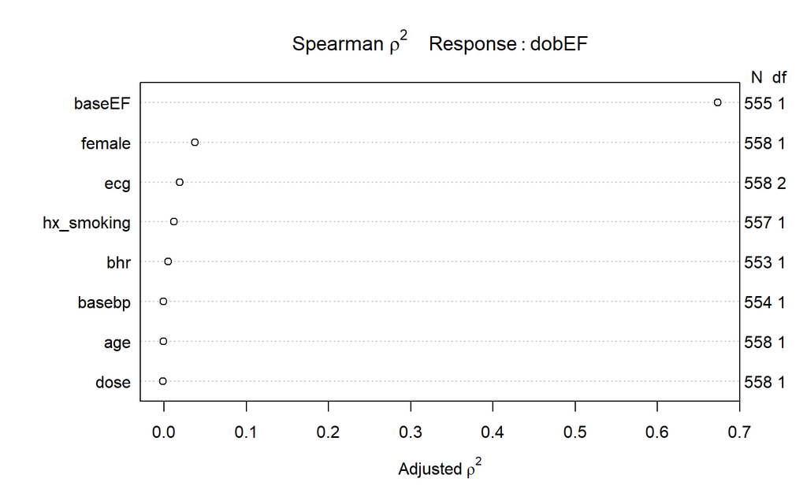

```r
plot(spearman2(dobEF ~ age + female + bhr + basebp + baseEF + hx_smoking + dose + ecg, data = stressEcho))
```

# 8 Task 8: Logistic Model Plans

We will predict the binary outcome **event** using some combination of the following ten variables:

- `age`
- `female`
- `bhr`
- `basebp`
- `baseEF`
- `dobEF`
- `hx_smoking`
- `ecg`
- `chestpain_c`
- `SE_res`

Here, knowing essentially nothing about it, we might expect that ejection fraction and `ecg` status would be of primary importance. Again, the cardiologists in the room will have better insight.

## 8.1 Spearman $\rho^2$ Plot

A Spearman $\rho^2$ plot certainly seems to back up the notion that the ejection fraction information and `ecg` status are important, but the `SE_res` is even more important. Of course, that makes sense. Again, here we fit this plot without accounting for missing predictor values.

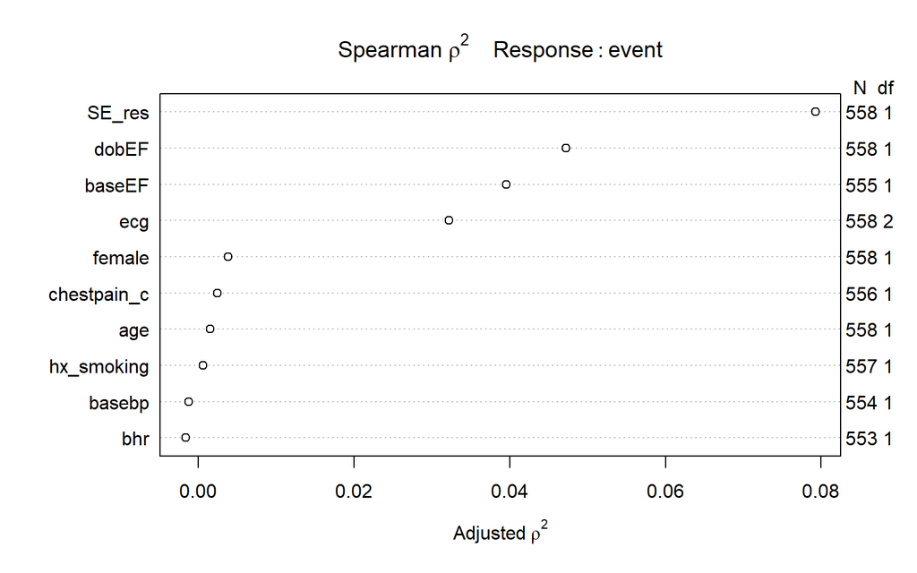

```r
plot(spearman2(event ~ age + female + bhr + basebp + baseEF + dobEF + hx_smoking + ecg + chestpain_c + SE_res, data = stressEcho))
```

# 9 Task 9: Affirmation

This data set meets all requirements specified in the project instructions.

# 10 An Analysis: Linear Regression

We’ll start with a model motivated by the Spearman $\rho^2$ plot developed previously, and repeated below.

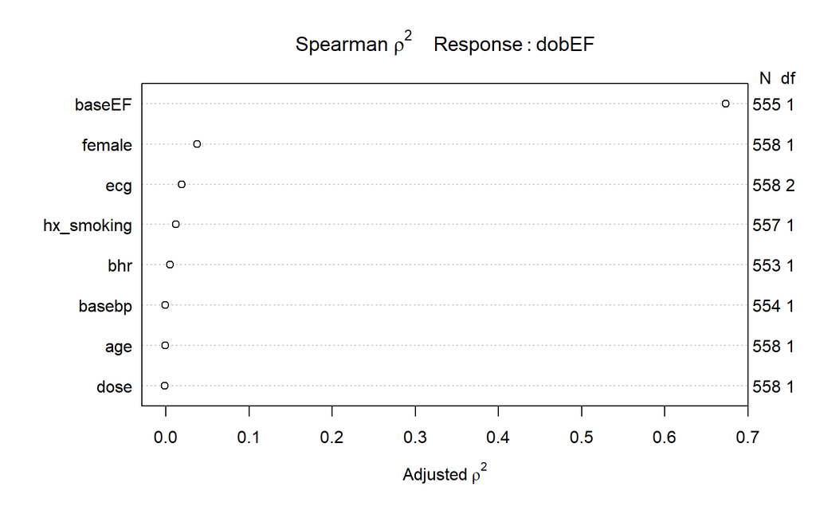

```r
plot(spearman2(dobEF ~ age + female + bhr + basebp + baseEF + hx_smoking + dose + ecg, data = stressEcho))
```

## 10.1 Model A. Modified Kitchen Sink

```r
d <- datadist(stressEcho)
options(datadist = "d")

m.A <- ols(dobEF ~ rcs(baseEF, 5) * female + ecg + hx_smoking +
               bhr + basebp + age + dose,
           data = stressEcho, x = T, y = T)
m.A
```

```
Frequencies of Missing Values Due to Each Variable
     dobEF     baseEF     female        ecg hx_smoking        bhr
         0          3          0          0          1          5
    basebp        age       dose
         4          0          0

Linear Regression Model

 ols(formula = dobEF ~ rcs(baseEF, 5) * female + ecg + hx_smoking +
     bhr + basebp + age + dose, data = stressEcho, x = T, y = T)


                Model Likelihood     Discrimination
                   Ratio Test           Indexes
 Obs     545    LR chi2    931.32    R2       0.819
 sigma5.1065    d.f.           16    R2 adj   0.813
 d.f.    528    Pr(> chi2) 0.0000    g       10.966

 Residuals

     Min      1Q  Median      3Q     Max
 -13.962  -3.144  -0.295   3.000  20.075


                    Coef    S.E.    t     Pr(>|t|)
 Intercept           6.7263  4.1431  1.62 0.1051
 baseEF              1.0112  0.0922 10.96 <0.0001
 baseEF'             0.1631  0.1929  0.85 0.3982
 baseEF''           -9.9655 10.3468 -0.96 0.3359
 baseEF'''          15.0780 20.1615  0.75 0.4549
 female              2.1309  5.3643  0.40 0.6914
 ecg=Equivocal       0.2276  0.5002  0.46 0.6493
 ecg=MI             -1.0219  0.6947 -1.47 0.1419
 hx_smoking=smoker  -0.6023  0.4551 -1.32 0.1862
 bhr                 0.0170  0.0148  1.15 0.2500
 basebp             -0.0032  0.0109 -0.30 0.7666
 age                -0.0304  0.0193 -1.58 0.1149
 dose                0.0743  0.0278  2.67 0.0078
 baseEF * female    -0.0262  0.1430 -0.18 0.8548
 baseEF' * female   -0.0454  0.2781 -0.16 0.8704
 baseEF'' * female   1.5479 13.4901  0.11 0.9087
 baseEF''' * female  1.0373 25.6033  0.04 0.9677
```

### 10.1.1 ANOVA plot

```r
anova(m.A)
```

```
                Analysis of Variance          Response: dobEF

 Factor                                         d.f. Partial SS
 baseEF  (Factor+Higher Order Factors)            8  55935.89563
  All Interactions                                4     69.21023
  Nonlinear (Factor+Higher Order Factors)         6    176.71235
 female  (Factor+Higher Order Factors)            5    108.55325
  All Interactions                                4     69.21023
 ecg                                              2     77.79306
 hx_smoking                                       1     45.68648
 bhr                                              1     34.59033
 basebp                                           1      2.30054
 age                                              1     65.02396
 dose                                             1    185.73211
 baseEF * female  (Factor+Higher Order Factors)   4     69.21023
  Nonlinear                                       3     69.11221
  Nonlinear Interaction : f(A,B) vs. AB           3     69.11221
 TOTAL NONLINEAR                                  6    176.71235
 TOTAL NONLINEAR + INTERACTION                    7    183.33261
 REGRESSION                                      16  62269.52356
 ERROR                                          528  13768.50580
 MS         F      P
 6991.98695 268.13 <.0001
   17.30256   0.66 0.6176
   29.45206   1.13 0.3437
   21.71065   0.83 0.5269
   17.30256   0.66 0.6176
   38.89653   1.49 0.2260
   45.68648   1.75 0.1862
   34.59033   1.33 0.2500
    2.30054   0.09 0.7666
   65.02396   2.49 0.1149
  185.73211   7.12 0.0078
   17.30256   0.66 0.6176
   23.03740   0.88 0.4494
   23.03740   0.88 0.4494
   29.45206   1.13 0.3437
   26.19037   1.00 0.4271
 3891.84522 149.25 <.0001
   26.07672
```

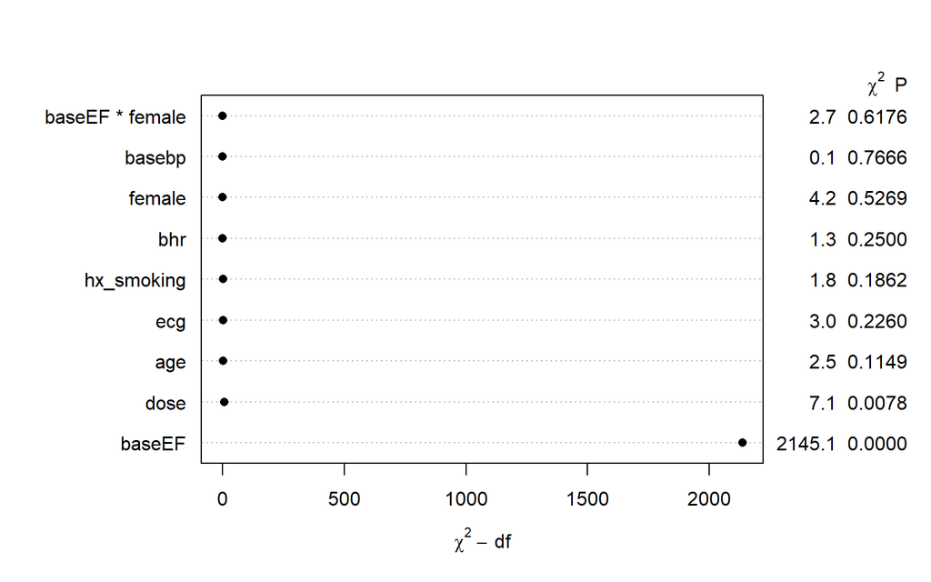

```r
plot(anova(m.A))
```

According to the ANOVA, `baseEF` and `dose` are the only statistically significant pieces of the puzzle, and the nonlinear part of the model doesn’t seem to have a real impact. Later, we’ll use the “Best Subsets” approach to do some variable selection. But first, let’s run this Model A again, but this time accounting for the missing values through multiple imputation.

## 10.2 Model A (with imputation)

### 10.2.1 Imputation Model

I’ll build the imputation model using my outcome, and the variables with at least one missing value, in this case.

```r
f.A <- aregImpute(~ dobEF + baseEF + bhr + basebp +
                      hx_smoking,
                  data = stressEcho,
                  n.impute = 100,
                  pr = FALSE, x = TRUE)
f.A
```

```
Multiple Imputation using Bootstrap and PMM

aregImpute(formula = ~dobEF + baseEF + bhr + basebp + hx_smoking,
    data = stressEcho, n.impute = 100, x = TRUE, pr = FALSE)

n: 558  p: 5    Imputations: 100    nk: 3

Number of NAs:
     dobEF     baseEF        bhr     basebp hx_smoking
         0          3          5          4          1

           type d.f.
dobEF         s    2
baseEF        s    2
bhr           s    2
basebp        s    2
hx_smoking    c    1

Transformation of Target Variables Forced to be Linear

R-squares for Predicting Non-Missing Values for Each Variable
Using Last Imputations of Predictors
    baseEF        bhr     basebp hx_smoking
     0.801      0.036      0.020      0.028
```

### 10.2.2 Fitting the Model after Imputation

```r
fmi.m.A <- fit.mult.impute(dobEF ~ rcs(baseEF, 5) * female + ecg +
                               hx_smoking + bhr + basebp + age +
                               dose,
                           ols, f.A, data = stressEcho)
```

```
Variance Inflation Factors Due to Imputation:

         Intercept             baseEF            baseEF'
              1.00               1.00               1.00
          baseEF''          baseEF'''             female
              1.00               1.00               1.00
     ecg=Equivocal             ecg=MI  hx_smoking=smoker
              1.00               1.00               1.00
               bhr             basebp                age
              1.01               1.01               1.01
              dose    baseEF * female   baseEF' * female
              1.00               1.00               1.00
 baseEF'' * female baseEF''' * female
              1.01               1.00

Rate of Missing Information:

         Intercept             baseEF            baseEF'
              0.00               0.00               0.00
          baseEF''          baseEF'''             female
              0.00               0.00               0.00
     ecg=Equivocal             ecg=MI  hx_smoking=smoker
              0.00               0.00               0.00
               bhr             basebp                age
              0.01               0.01               0.01
              dose    baseEF * female   baseEF' * female
              0.00               0.00               0.00
 baseEF'' * female baseEF''' * female
              0.01               0.00

d.f. for t-distribution for Tests of Single Coefficients:

         Intercept             baseEF            baseEF'
          31949177          120397468           25558888
          baseEF''          baseEF'''             female
           9585996            9804629          192752975
     ecg=Equivocal             ecg=MI  hx_smoking=smoker
           5668000           64398191           28684692
               bhr             basebp                age
           1892670            1219133            2824200
              dose    baseEF * female   baseEF' * female
          48166746           37006330            4462533
 baseEF'' * female baseEF''' * female
           3458845            4016519

The following fit components were averaged over the 100 model fits:

  fitted.values stats linear.predictors
```

```r
fmi.m.A
```

```
Linear Regression Model

 fit.mult.impute(formula = dobEF ~ rcs(baseEF, 5) * female + ecg +
     hx_smoking + bhr + basebp + age + dose, fitter = ols, xtrans = f.A,
     data = stressEcho)

                Model Likelihood     Discrimination
                   Ratio Test           Indexes
 Obs     558    LR chi2    949.82    R2       0.818
 sigma5.0956    d.f.           16    R2 adj   0.812
 d.f.    541    Pr(> chi2) 0.0000    g       10.889

 Residuals

      Min       1Q   Median       3Q      Max
 -14.1004  -3.1421  -0.3213   3.0172  19.6619


                    Coef    S.E.    t     Pr(>|t|)
 Intercept           6.6206  4.1036  1.61 0.1072
 baseEF              1.0129  0.0913 11.10 <0.0001
 baseEF'             0.1570  0.1891  0.83 0.4069
 baseEF''           -9.9198 10.1610 -0.98 0.3294
 baseEF'''          15.1036 19.8443  0.76 0.4469
 female              1.8716  5.3427  0.35 0.7263
 ecg=Equivocal       0.1641  0.4945  0.33 0.7401
 ecg=MI             -1.0220  0.6849 -1.49 0.1362
 hx_smoking=smoker  -0.5703  0.4494 -1.27 0.2049
 bhr                 0.0153  0.0147  1.04 0.2979
 basebp             -0.0021  0.0108 -0.20 0.8427
 age                -0.0285  0.0190 -1.50 0.1344
 dose                0.0749  0.0275  2.73 0.0066
 baseEF * female    -0.0208  0.1423 -0.15 0.8839
 baseEF' * female   -0.0501  0.2752 -0.18 0.8555
 baseEF'' * female   1.0212 13.3278  0.08 0.9390
 baseEF''' * female  2.3403 25.3121  0.09 0.9264
```

### 10.2.3 ANOVA plot after imputation

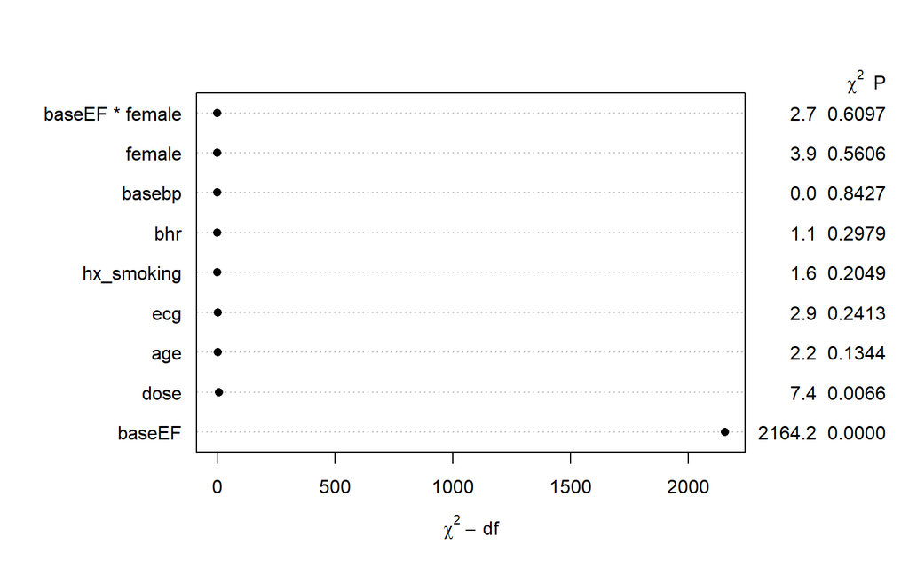

```r
plot(anova(fmi.m.A))
```

### 10.2.4 Effects plot after imputation

```r
summary(fmi.m.A)
```

```
             Effects              Response : dobEF

 Factor                         Low High Diff. Effect    S.E.
 baseEF                          52  62  10     9.948500 0.92424
 female                           0   1   1     0.033274 0.86613
 bhr                             64  84  20     0.306360 0.29402
 basebp                         120 150  30    -0.064482 0.32475
 age                             60  75  15    -0.427040 0.28484
 dose                            30  40  10     0.748960 0.27475
 ecg - Equivocal:Normal           1   2  NA     0.164090 0.49449
 ecg - MI:Normal                  1   3  NA    -1.022000 0.68490
 hx_smoking - smoker:non-smoker   1   2  NA    -0.570340 0.44936
 Lower 0.95 Upper 0.95
  8.13300   11.76400
 -1.66810    1.73470
 -0.27120    0.88391
 -0.70240    0.57344
 -0.98657    0.13249
  0.20926    1.28870
 -0.80726    1.13550
 -2.36740    0.32339
 -1.45300    0.31236

Adjusted to: baseEF=57 female=0
```

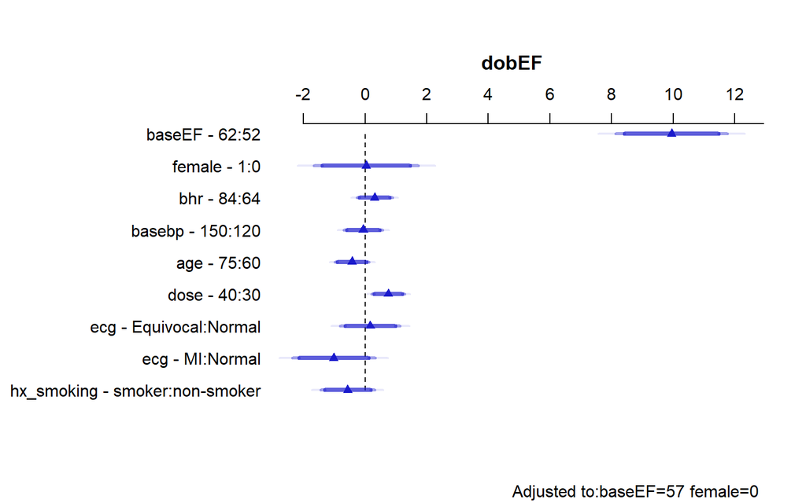

```r
plot(summary(fmi.m.A))
```

### 10.2.5 Nomogram after imputation

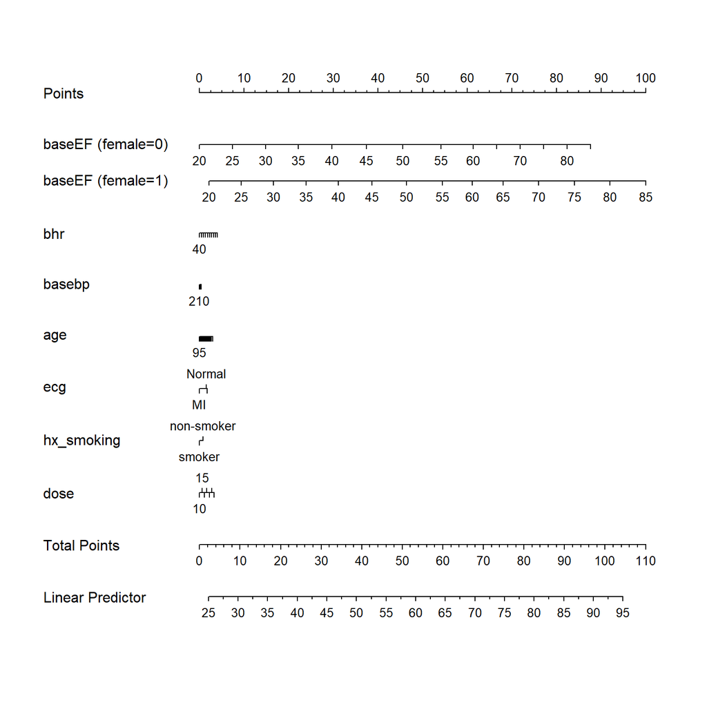

```r
plot(nomogram(fmi.m.A))
```

## 10.3 Running “Best Subsets” to select predictors

Mostly for completeness, next we’ll consider models with main effects only, again just excluding the observations with missing values, and run our “best subsets” comparisons to consider potential models.

```r
preds <- with(na.omit(stressEcho), cbind(baseEF, female, ecg, hx_smoking, bhr, basebp, age, dose))
x1 <- regsubsets(preds, na.omit(stressEcho)$dobEF, nvmax=8)
rs <- summary(x1)
rs
```

```
Subset selection object
8 Variables  (and intercept)
           Forced in Forced out
baseEF         FALSE      FALSE
female         FALSE      FALSE
ecg            FALSE      FALSE
hx_smoking     FALSE      FALSE
bhr            FALSE      FALSE
basebp         FALSE      FALSE
age            FALSE      FALSE
dose           FALSE      FALSE
1 subsets of each size up to 8
Selection Algorithm: exhaustive
         baseEF female ecg hx_smoking bhr basebp age dose
1  ( 1 ) "*"    " "    " " " "        " " " "    " " " "
2  ( 1 ) "*"    " "    " " " "        " " " "    " " "*"
3  ( 1 ) "*"    " "    " " " "        " " " "    "*" "*"
4  ( 1 ) "*"    "*"    " " " "        " " " "    "*" "*"
5  ( 1 ) "*"    "*"    " " "*"        " " " "    "*" "*"
6  ( 1 ) "*"    "*"    " " "*"        "*" " "    "*" "*"
7  ( 1 ) "*"    "*"    "*" "*"        "*" " "    "*" "*"
8  ( 1 ) "*"    "*"    "*" "*"        "*" "*"    "*" "*"
```

### 10.3.1 Building the Four Summary Plots

While there are `nrows(stressEcho)` rows in the `stressEcho` tibble, we have restricted ourselves here to the `nrows(na.omit(stressEcho))` rows in the tibble after we have applied tha `na.omit` function. We are fitting models including 1-8 predictors, hence 2-9 coefficients. In this case, I’ll use the old non-ggplot approach, although I expect that students in this year’s class will use the `ggplot2` approach.

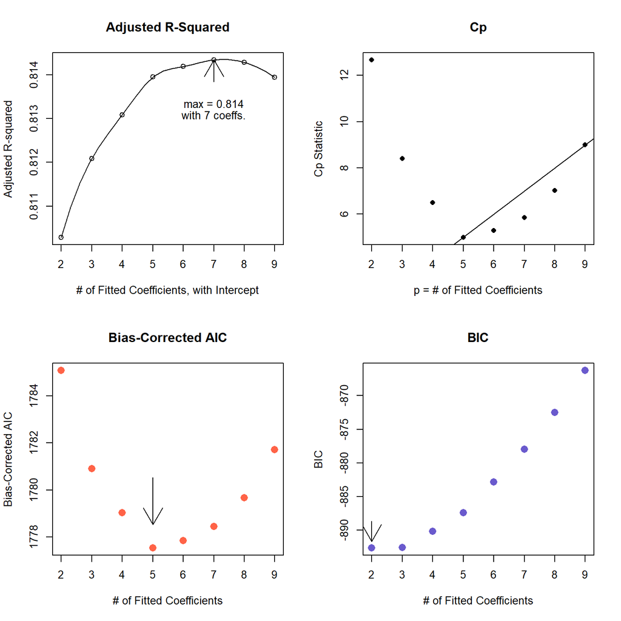

```r
# Note: 544 subjects, models for 1-8 predictors (2-9 coeffs.)

par(mfrow=c(2,2))

# Adjusted R-squared Plot
m2 <- max(rs$adjr2)
m1 <- which.max(rs$adjr2)
plot(rs$adjr2 ~ I(2:9), ylab="Adjusted R-squared",
     xlab="# of Fitted Coefficients, with Intercept",
     main="Adjusted R-Squared")
lines(spline(rs$adjr2 ~ I(2:9)))
arrows(m1+1, m2-0.0005, m1+1, m2)
text(m1+1, m2-0.001, paste("max =", format(m2, digits=3)))
text(m1+1, m2-0.0015, paste("with", format(m1+1, digits=1),
                        "coeffs."), pos=3)

# Cp Plot
plot(rs$cp ~ I(2:9),
     ylab="Cp Statistic",
     xlab="p = # of Fitted Coefficients",
     pch=16, main="Cp")
abline(0,1)

# Next calculate bias-corrected AIC
# recall n = 544, and we have 8 models
# so that's 2-9 coefficients to fit

rs$aic.corr <- 544*log(rs$rss / 544) + 2*(2:9) +
               (2 * (2:9) * ((2:9)+1) / (544 - (2:9) - 1))

# Bias-Corrected AIC plot with arrow included
# to indicate minimum AIC-corrected
m2 <- min(rs$aic.corr)
m1 <- which.min(rs$aic.corr)
plot(rs$aic.corr ~ I(2:9), ylab="Bias-Corrected AIC",
     xlab="# of Fitted Coefficients", pch=16, cex=1.5,
     col="tomato", main="Bias-Corrected AIC")
arrows(m1+1, m2+3, m1+1, m2+1)

# plot BIC with indicating arrow for minimizer
m2 <- min(rs$bic)
m1 <- which.min(rs$bic)
plot(rs$bic ~ I(2:9), ylab="BIC", xlab="# of Fitted Coefficients",
     pch=16, cex=1.5, col="slateblue", main="BIC")
arrows(m1+1, m2+4, m1+1, m2+1)
```

```r
par(mfrow=c(1,1))
```

### 10.3.2 Candidate Models from “Best Subsets”

| Tool | Inputs | Predictors |
| --- | --- | --- |
| BIC | 2 | `baseEF` |
| AIC<sub>c</sub>, C<sub>p</sub> | 5 | `baseEF`, `dose`, `age`, `female` |
| R<sup>2</sup> (adj.) | 7 | `baseEF`, `dose`, `age`, `female`, `hx_smoking`, `bhr` |

### 10.3.3 Comparison of Candidate Models via ANOVA

```r
lm0 <- lm(dobEF ~ 1, data = na.omit(stressEcho))
lm2 <- lm(dobEF ~ baseEF + female, data = na.omit(stressEcho))
lm5 <- lm(dobEF ~ baseEF + female + age + dose, data = na.omit(stressEcho))
lm7 <- lm(dobEF ~ baseEF + female + hx_smoking + bhr + basebp + age + dose,
           data = na.omit(stressEcho))
lm8 <- lm(dobEF ~ baseEF + female + ecg + hx_smoking + bhr + basebp + age + dose,
           data = na.omit(stressEcho))
```

```r
anova(lm8, lm7, lm5, lm2, lm0)
```

```
Analysis of Variance Table

Model 1: dobEF ~ baseEF + female + ecg + hx_smoking + bhr + basebp + age +
    dose
Model 2: dobEF ~ baseEF + female + hx_smoking + bhr + basebp + age + dose
Model 3: dobEF ~ baseEF + female + age + dose
Model 4: dobEF ~ baseEF + female
Model 5: dobEF ~ 1
  Res.Df   RSS Df Sum of Sq         F    Pr(>F)
1    534 13860
2    536 13933 -2       -72    1.3959  0.248505
3    539 14015 -3       -82    1.0538  0.368349
4    541 14307 -2      -292    5.6166  0.003855 **
5    543 75888 -2    -61581 1186.2707 < 2.2e-16 ***
---
Signif. codes:  0 '***' 0.001 '**' 0.01 '*' 0.05 '.' 0.1 ' ' 1
```

The ANOVA suggests the model with four predictors, and five inputs (including the intercept). Let’s run that as our model B.

## 10.4 Model B

```r
m.B <- ols(dobEF ~ baseEF + female + age + dose,
           data = stressEcho, x = T, y = T)
m.B
```

```
Frequencies of Missing Values Due to Each Variable
 dobEF baseEF female    age   dose
     0      3      0      0      0

Linear Regression Model

 ols(formula = dobEF ~ baseEF + female + age + dose, data = stressEcho,
     x = T, y = T)


                Model Likelihood     Discrimination
                   Ratio Test           Indexes
 Obs     555    LR chi2    933.08    R2       0.814
 sigma5.1038    d.f.            4    R2 adj   0.813
 d.f.    550    Pr(> chi2) 0.0000    g       11.067

 Residuals

      Min       1Q   Median       3Q      Max
 -15.0904  -3.0488  -0.1399   2.9896  19.2256


           Coef    S.E.   t     Pr(>|t|)
 Intercept  7.7093 1.9608  3.93 <0.0001
 baseEF     1.0189 0.0216 47.26 <0.0001
 female     0.8110 0.4601  1.76 0.0785
 age       -0.0319 0.0180 -1.77 0.0776
 dose       0.0750 0.0269  2.79 0.0054
```

### 10.4.1 ANOVA plot for Model B

The ANOVA plot after an `ols` fit just re-iterates the information from the *t* tests.

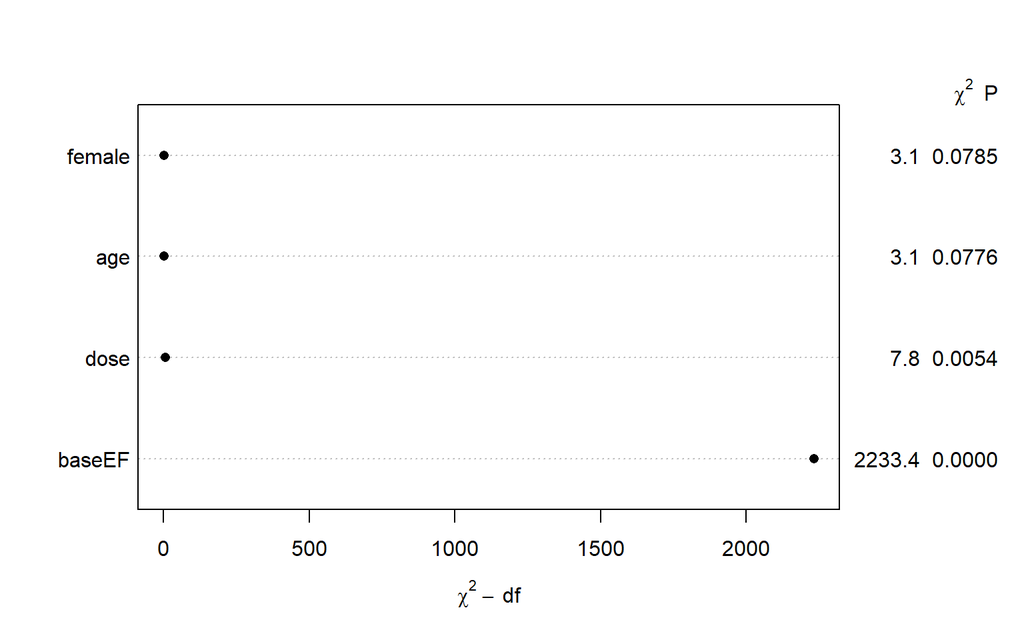

```r
plot(anova(m.B))
```

### 10.4.2 Validation of Model B Summary Statistics

```r
set.seed(432); validate(m.B)
```

```
          index.orig training    test optimism index.corrected  n
R-square      0.8139   0.8173  0.8121   0.0052          0.8087 40
MSE          25.8145  25.3533 26.0587  -0.7054         26.5199 40
g            11.0669  11.1206 11.0637   0.0569         11.0100 40
Intercept     0.0000   0.0000  0.2409  -0.2409          0.2409 40
Slope         1.0000   1.0000  0.9969   0.0031          0.9969 40
```

### 10.4.3 Nomogram of Model B

The nomogram is very simple, since each predictor only enters the model linearly.

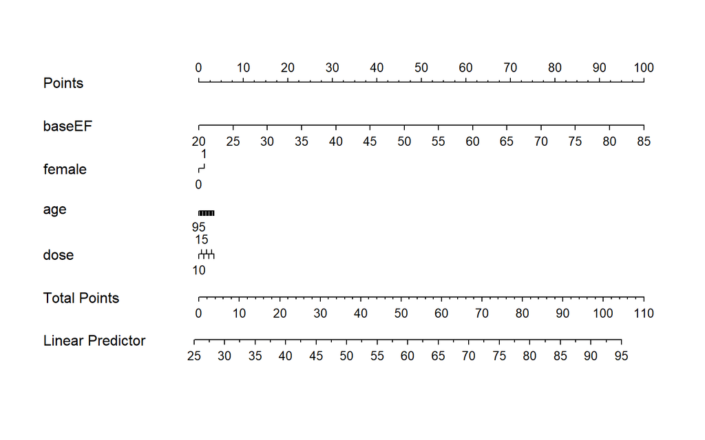

```r
plot(nomogram(m.B))
```

The `baseEF` really drives the model almost to the exclusion of everything else.

### 10.4.4 Some Predictions

Suppose we want to make a prediction with this Model B, where `baseEF` can vary from 20 to 80, and dose ranges from 10 to 40, while the other variables (`female` and `age`) remain at their medians. Can we plot the results?

```r
Predict(m.B, baseEF = seq(20, 80, 20), dose = c(10, 40))
```

```
  baseEF female age dose     yhat    lower    upper
1     20      0  69   10 26.63833 24.59888 28.67777
2     40      0  69   10 47.01674 45.42994 48.60355
3     60      0  69   10 67.39516 65.87482 68.91550
4     80      0  69   10 87.77357 85.89214 89.65501
5     20      0  69   40 28.88975 27.33082 30.44867
6     40      0  69   40 49.26816 48.36777 50.16856
7     60      0  69   40 69.64658 68.85535 70.43780
8     80      0  69   40 90.02499 88.65523 91.39475

Response variable (y): dobEF

Adjust to: female=0 age=69

Limits are 0.95 confidence limits
```

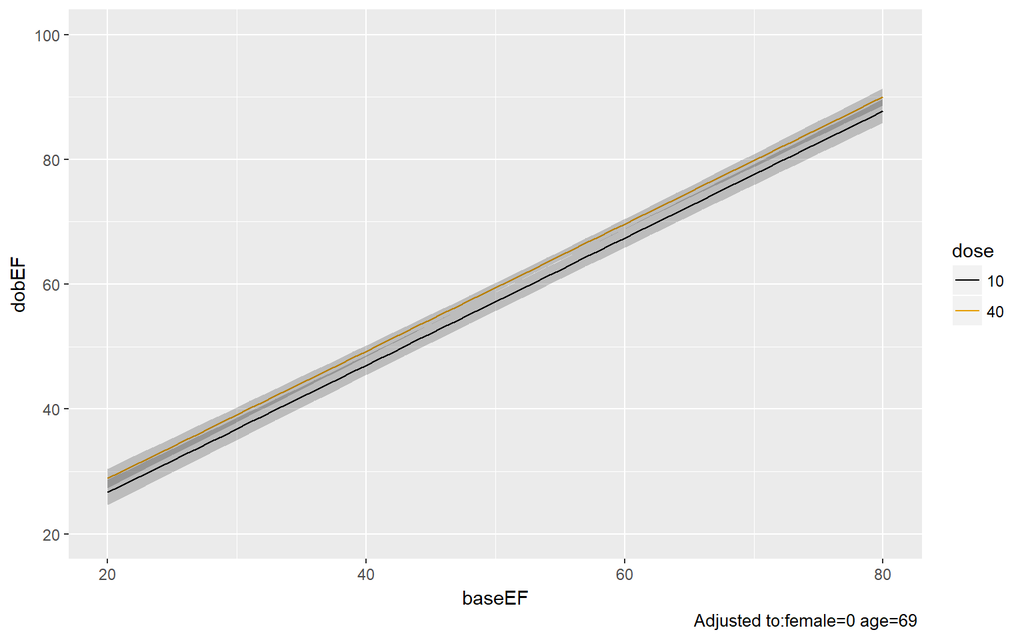

```r
ggplot(Predict(m.B, baseEF = 20:80, dose = c(10, 40)))
```

Does the `dose` really have a noticeable impact, once we know the baseline ejection fraction?

### 10.4.5 Fitting Model B with `lm`

We can fit Model B using `lm` and then plot residuals, if we like.

```r
model.B <- lm(dobEF ~ baseEF + female + age + dose,
              data = stressEcho)
display(model.B)
```

```
lm(formula = dobEF ~ baseEF + female + age + dose, data = stressEcho)
            coef.est coef.se
(Intercept)  7.71     1.96
baseEF       1.02     0.02
female       0.81     0.46
age         -0.03     0.02
dose         0.08     0.03
---
n = 555, k = 5
residual sd = 5.10, R-Squared = 0.81
```

### 10.4.6 Residual Plots for Model B

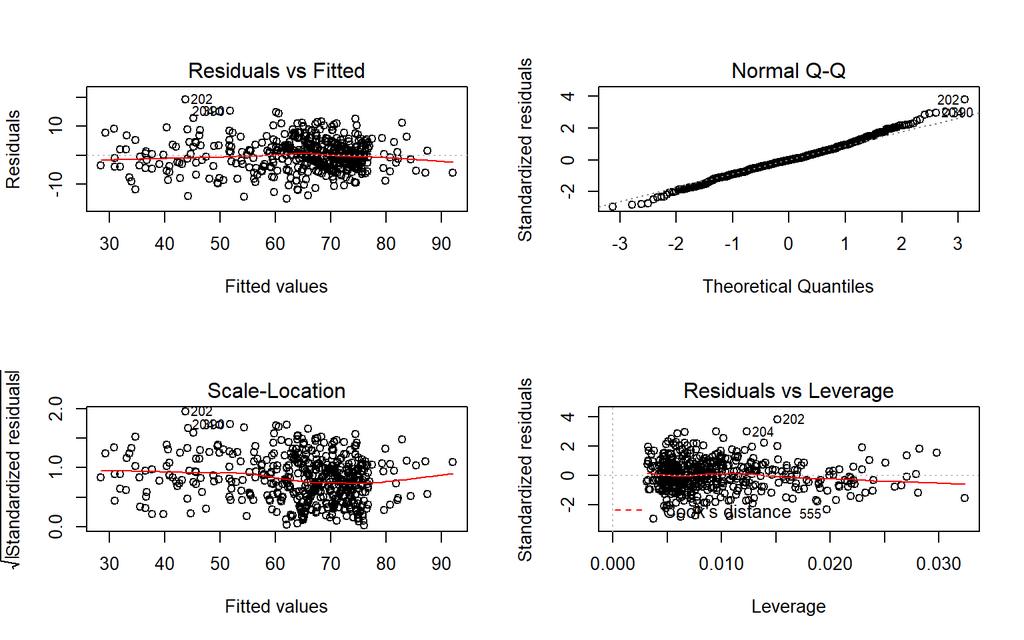

```r
par(mfrow=c(2,2))
plot(model.B)
```

```r
par(mfrow=c(1,1))
```

# 11 An Analysis: Logistic Regression

We’ll start with a model motivated by the Spearman $\rho^2$ plot developed above, and repeated below.

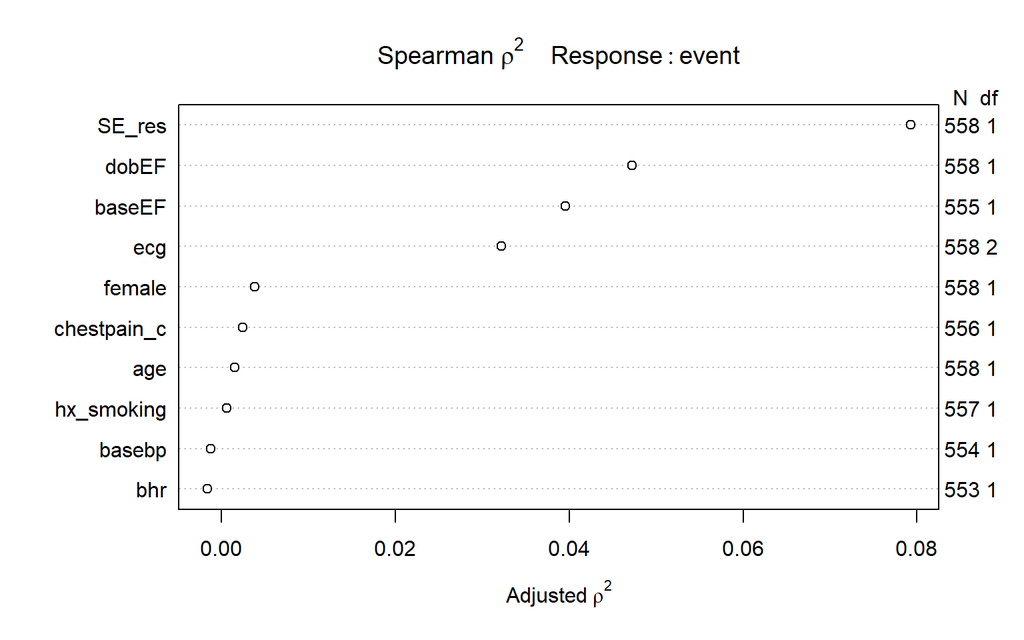

```r
plot(spearman2(event ~ age + female + bhr + basebp +
                   baseEF + dobEF + hx_smoking + ecg +
                   chestpain_c + SE_res,
               data = stressEcho))
```

## 11.1 Model 1 (a screening model - essentially the kitchen sink)

Our model (m.1) will include restricted cubic splines with four knots for the two ejection fraction variables, interaction terms between `SE_res` and `dobEF`, as well as `SE_res` and `ecg`, and then main effects of the other six candidate predictors. We’ll ignore the potential impact of missing data, and just fit the model to the complete cases. Another, probably better, option would have been to first do simple imputation and then move forward.

```r
dd <- datadist(stressEcho)
options(datadist = "dd")
m.1 <- lrm(event ~ SE_res * ecg + rcs(dobEF,4) * SE_res + rcs(baseEF,4) +
               female + chestpain_c + age + hx_smoking + basebp + bhr,
           data = stressEcho, x = T, y = T)
m.1
```

```
Frequencies of Missing Values Due to Each Variable
      event      SE_res         ecg       dobEF      baseEF      female
          0           0           0           0           3           0
chestpain_c         age  hx_smoking      basebp         bhr
          2           0           1           4           5

Logistic Regression Model

 lrm(formula = event ~ SE_res * ecg + rcs(dobEF, 4) * SE_res +
     rcs(baseEF, 4) + female + chestpain_c + age + hx_smoking +
     basebp + bhr, data = stressEcho, x = T, y = T)


                       Model Likelihood     Discrimination    Rank Discrim.
                          Ratio Test           Indexes           Indexes
 Obs           544    LR chi2      83.35    R2       0.242    C       0.782
  0            456    d.f.            20    g        1.219    Dxy     0.564
  1             88    Pr(> chi2) <0.0001    gr       3.383    gamma   0.565
 max |deriv| 8e-09                          gp       0.155    tau-a   0.153
                                            Brier    0.112

                                 Coef    S.E.   Wald Z Pr(>|Z|)
 Intercept                        0.7004 2.0914  0.33  0.7377
 SE_res=Positive                 -0.8905 2.1455 -0.42  0.6781
 ecg=Equivocal                    0.3132 0.3960  0.79  0.4289
 ecg=MI                           1.1613 0.5142  2.26  0.0239
 dobEF                           -0.1331 0.0536 -2.48  0.0130
 dobEF'                           0.0641 0.0826  0.78  0.4376
 dobEF''                          0.4027 1.4230  0.28  0.7772
 baseEF                           0.0808 0.0511  1.58  0.1140
 baseEF'                         -0.0943 0.0661 -1.43  0.1538
 baseEF''                         0.9507 1.2658  0.75  0.4526
 female                          -0.0175 0.2804 -0.06  0.9504
 chestpain_c=1                    0.1736 0.2810  0.62  0.5366
 age                              0.0039 0.0117  0.33  0.7401
 hx_smoking=smoker                0.0638 0.2663  0.24  0.8108
 basebp                           0.0055 0.0062  0.88  0.3777
 bhr                              0.0018 0.0088  0.20  0.8395
 SE_res=Positive * ecg=Equivocal -0.5459 0.6025 -0.91  0.3649
 SE_res=Positive * ecg=MI        -0.7456 0.7131 -1.05  0.2958
 SE_res=Positive * dobEF          0.0342 0.0464  0.74  0.4609
 SE_res=Positive * dobEF'         0.0446 0.0931  0.48  0.6316
 SE_res=Positive * dobEF''       -0.9495 1.8448 -0.51  0.6068
```

### 11.1.1 ANOVA for Model 1

The ANOVA plot from `rms` is one of the nicer features of building a model with `rms`, in my view.

```r
anova(m.1)
```

```
                Wald Statistics          Response: event

 Factor                                        Chi-Square d.f. P
 SE_res  (Factor+Higher Order Factors)         27.60       6   0.0001
  All Interactions                              9.15       5   0.1031
 ecg  (Factor+Higher Order Factors)             7.01       4   0.1356
  All Interactions                              1.36       2   0.5072
 dobEF  (Factor+Higher Order Factors)          13.14       6   0.0409
  All Interactions                              7.27       3   0.0637
  Nonlinear (Factor+Higher Order Factors)       6.14       4   0.1890
 baseEF                                         2.97       3   0.3964
  Nonlinear                                     2.86       2   0.2396
 female                                         0.00       1   0.9504
 chestpain_c                                    0.38       1   0.5366
 age                                            0.11       1   0.7401
 hx_smoking                                     0.06       1   0.8108
 basebp                                         0.78       1   0.3777
 bhr                                            0.04       1   0.8395
 SE_res * ecg  (Factor+Higher Order Factors)    1.36       2   0.5072
 SE_res * dobEF  (Factor+Higher Order Factors)  7.27       3   0.0637
  Nonlinear                                     0.27       2   0.8748
  Nonlinear Interaction : f(A,B) vs. AB         0.27       2   0.8748
 TOTAL NONLINEAR                                8.17       6   0.2256
 TOTAL INTERACTION                              9.15       5   0.1031
 TOTAL NONLINEAR + INTERACTION                 15.43       9   0.0797
 TOTAL                                         68.98      20   <.0001
```

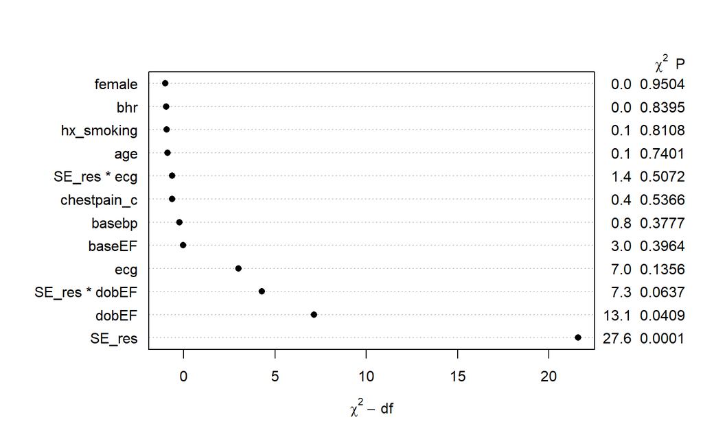

```r
plot(anova(m.1))
```

From the ANOVA plot, it looks like a model with `SE_res` and `dobEF`, plus maybe their interaction, might be sufficient, ignoring the missing data.

### 11.1.2 Plotting Predictions from Model 1

We can use `ggplot` and the `Predict` function from `rms` to plot predictions across a range of levels for up to three predictors simultaneously, as long as only one of them is quantitative. Here, we’ll build a plot of the predicted event probabilities according to the model, while letting:

- `dobEF` range from 60 to 85
- for each level of `SE_res` and of `ecg`
- while holding all other variables at their medians.

The `fun = plogis` command here plots the probabilities, rather than the log odds.

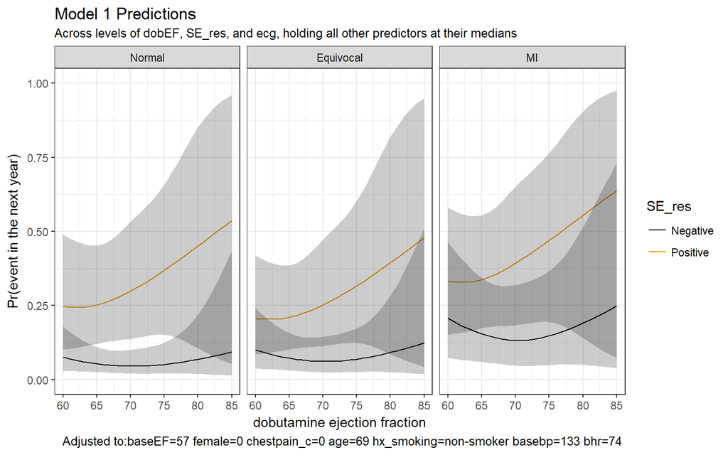

```r
ggplot(Predict(m.1, dobEF = 60:85, SE_res, ecg, fun=plogis)) +
    theme_bw() +
    labs(x = "dobutamine ejection fraction",
         y = "Pr(event in the next year)",
         title = "Model 1 Predictions",
         subtitle = "Across levels of dobEF, SE_res, and ecg, holding all other predictors at their medians")
```

### 11.1.3 Plotting the ROC curve for Model 1

First, we need to fit Model 1 in `glm`, rather than `rms`.

```r
model.1 <- glm(event ~ SE_res * ecg + rcs(dobEF,4) * SE_res +
                   rcs(baseEF,4) + female + chestpain_c + age +
                   hx_smoking + basebp + bhr,
               data = stressEcho, family = binomial(link = logit))
```

We have to omit the missing values from `stressEcho` in the first two lines below in order to get the ROC curve to run.

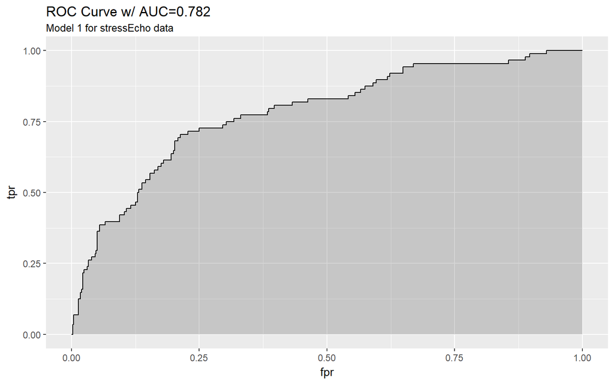

```r
# requires ROCR package
prob <- predict(model.1, data = na.omit(stressEcho), type="response")
pred <- prediction(prob, na.omit(stressEcho)$event)
# rest of this doesn't need much adjustment except for titles
perf <- performance(pred, measure = "tpr", x.measure = "fpr")
auc <- performance(pred, measure="auc")
auc <- round(auc@y.values[[1]],3)
roc.data <- data.frame(fpr=unlist(perf@x.values),
                       tpr=unlist(perf@y.values),
                       model="GLM")
ggplot(roc.data, aes(x=fpr, ymin=0, ymax=tpr)) +
    geom_ribbon(alpha=0.2) +
    geom_line(aes(y=tpr)) +
    labs(title = paste0("ROC Curve w/ AUC=", auc),
         subtitle = "Model 1 for stressEcho data")
```

### 11.1.4 Coefficients from Model 1 on the Odds Ratio Scale

It’s difficult to interpret odds ratios well from a logistic regression model with non-linear terms.

Suppose we look specifically at the `female` variable. What can we conclude about that specific predictor, which only enters the model in a linear way? Note that it helps that there are no missing values in the `female` data.

```r
exp(coef(model.1)[c("female")])
```

```
   female
0.9826954
```

```r
exp(confint(model.1)[c("female"),])
```

```
    2.5 %    97.5 %
0.5689694 1.7127775
```

Now, what about a predictor, like `chestpain_c`, with some missing values? In that case, we need to refit the model to use only the complete cases in the stressEcho data set.

```r
model.1a <- glm(event ~ SE_res * ecg + rcs(dobEF,4) * SE_res +
                   rcs(baseEF,4) + female + chestpain_c + age +
                   hx_smoking + basebp + bhr,
               data = na.omit(stressEcho),
               family = binomial(link = logit))

display(model.1a)
```

```
glm(formula = event ~ SE_res * ecg + rcs(dobEF, 4) * SE_res +
    rcs(baseEF, 4) + female + chestpain_c + age + hx_smoking +
    basebp + bhr, family = binomial(link = logit), data = na.omit(stressEcho))
                                    coef.est coef.se
(Intercept)                          0.70     2.09
SE_resPositive                      -0.89     2.15
ecgEquivocal                         0.31     0.40
ecgMI                                1.16     0.51
rcs(dobEF, 4)dobEF                  -0.13     0.05
rcs(dobEF, 4)dobEF'                  0.06     0.08
rcs(dobEF, 4)dobEF''                 0.40     1.42
rcs(baseEF, 4)baseEF                 0.08     0.05
rcs(baseEF, 4)baseEF'               -0.09     0.07
rcs(baseEF, 4)baseEF''               0.95     1.27
female                              -0.02     0.28
chestpain_c1                         0.17     0.28
age                                  0.00     0.01
hx_smokingsmoker                     0.06     0.27
basebp                               0.01     0.01
bhr                                  0.00     0.01
SE_resPositive:ecgEquivocal         -0.55     0.60
SE_resPositive:ecgMI                -0.75     0.71
SE_resPositive:rcs(dobEF, 4)dobEF    0.03     0.05
SE_resPositive:rcs(dobEF, 4)dobEF'   0.04     0.09
SE_resPositive:rcs(dobEF, 4)dobEF'' -0.95     1.84
---
  n = 544, k = 21
  residual deviance = 398.2, null deviance = 481.5 (difference = 83.3)
```

```r
exp(coef(model.1a)[c("chestpain_c1")])
```

```
chestpain_c1
    1.189595
```

```r
exp(confint(model.1a)[c("chestpain_c1"),])
```

```
    2.5 %    97.5 %
0.6812227 2.0556107
```

Holding everything else constant (a tall order in this setting), we see a modest (but not significant) association between chestpain_c and having an event.

Specifically, the odds ratio associated with having chest pain vs. not having chest pain on experiencing an event is estimated to be 1.19 (95% CI: 0.68, 2.06). This implies that the odds of having an event increase by a factor of about 1.19 (about 19%) when a patient has chest pain as compared to an otherwise identical patient without chest pain.

### 11.1.5 Calibration Plot for Model 1

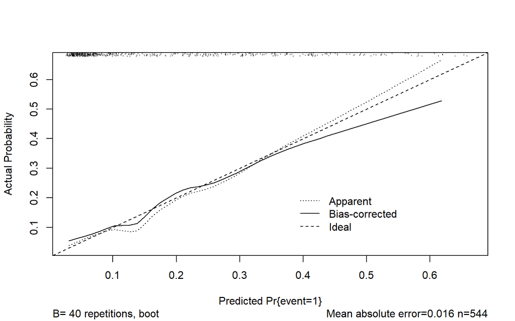

```
n=544   Mean absolute error=0.016   Mean squared error=0.00043
0.9 Quantile of absolute error=0.023
```

```r
plot(calibrate(m.1))
```

Model 1 appears to overpredict a bit, especially at the higher predicted values.

### 11.1.6 Validation of Model 1, with backwards elimination

What if we try a validation step, with a stepwise backwards elimination approach?

```r
set.seed(432); validate(m.1, bw = TRUE, B = 10)
```

```
        Backwards Step-down - Original Model

 Deleted      Chi-Sq d.f. P      Residual d.f. P      AIC
 baseEF       2.97   3    0.3964  2.97     3   0.3964  -3.03
 SE_res * ecg 2.01   2    0.3668  4.98     5   0.4189  -5.02
 female       0.00   1    0.9464  4.98     6   0.5464  -7.02
 bhr          0.03   1    0.8572  5.01     7   0.6585  -8.99
 hx_smoking   0.05   1    0.8296  5.06     8   0.7513 -10.94
 age          0.16   1    0.6871  5.22     9   0.8147 -12.78
 SE_res       0.20   1    0.6587  5.42    10   0.8617 -14.58
 chestpain_c  0.64   1    0.4219  6.06    11   0.8693 -15.94
 basebp       0.86   1    0.3542  6.92    12   0.8629 -17.08
 ecg          5.53   2    0.0630 12.45    14   0.5704 -15.55

Approximate Estimates after Deleting Factors

                              Coef     S.E.  Wald Z      P
Intercept                  1.70744 1.040971  1.6402 0.1010
dobEF                     -0.05596 0.023360 -2.3955 0.0166
dobEF'                    -0.04093 0.052174 -0.7845 0.4328
dobEF''                    1.53397 1.053463  1.4561 0.1454
SE_res=Positive * dobEF    0.01198 0.009267  1.2933 0.1959
SE_res=Positive * dobEF'   0.06843 0.057074  1.1989 0.2305
SE_res=Positive * dobEF'' -1.24007 1.490847 -0.8318 0.4055

Factors in Final Model

[1] dobEF          SE_res * dobEF
```

```
          index.orig training    test optimism index.corrected  n
Dxy           0.5198   0.5547  0.4804   0.0744          0.4454 10
R2            0.2088   0.2373  0.1711   0.0662          0.1426 10
Intercept     0.0000   0.0000 -0.2288   0.2288         -0.2288 10
Slope         1.0000   1.0000  0.8229   0.1771          0.8229 10
Emax          0.0000   0.0000  0.0875   0.0875          0.0875 10
D             0.1290   0.1488  0.1043   0.0445          0.0845 10
U            -0.0037  -0.0037  0.0073  -0.0109          0.0073 10
Q             0.1327   0.1525  0.0971   0.0554          0.0772 10
B             0.1162   0.1110  0.1209  -0.0100          0.1261 10
g             1.0722   1.1503  0.9354   0.2148          0.8573 10
gp            0.1422   0.1464  0.1253   0.0211          0.1211 10

Factors Retained in Backwards Elimination

 SE_res ecg dobEF baseEF female chestpain_c age hx_smoking basebp bhr
            *
        *   *
            *
 *          *
            *
        *   *
 *          *
 *
        *   *     *                                               *
            *
 SE_res * ecg SE_res * dobEF
              *

 *

              *
              *


 *            *
              *

Frequencies of Numbers of Factors Retained

1 2 3 6
1 7 1 1
```

So, it looks like this model is pretty seriously overfitting the data. The next model to try involves only `SE_res` and `dobEF` with an interaction between them and a restricted cubic spline for `dobEF`. We’ll look at that in Model 2.

## 11.2 Model 2 (a smaller model with promising predictors)

Let’s run our Model 2.

```r
dd <- datadist(stressEcho)
options(datadist = "dd")
m.2 <- lrm(event ~ SE_res * rcs(dobEF,4),
           data = stressEcho, x = T, y = T)
m.2
```

```
Logistic Regression Model

 lrm(formula = event ~ SE_res * rcs(dobEF, 4), data = stressEcho,
     x = T, y = T)

                       Model Likelihood     Discrimination    Rank Discrim.
                          Ratio Test           Indexes           Indexes
 Obs           558    LR chi2      73.68    R2       0.211    C       0.762
  0            468    d.f.             7    g        1.072    Dxy     0.524
  1             90    Pr(> chi2) <0.0001    gr       2.921    gamma   0.538
 max |deriv| 4e-10                          gp       0.143    tau-a   0.142
                                            Brier    0.116

                           Coef    S.E.   Wald Z Pr(>|Z|)
 Intercept                  2.2730 1.5324  1.48  0.1380
 SE_res=Positive           -1.0571 2.0591 -0.51  0.6077
 dobEF                     -0.0693 0.0336 -2.06  0.0395
 dobEF'                    -0.0249 0.0651 -0.38  0.7022
 dobEF''                    1.3608 1.1836  1.15  0.2503
 SE_res=Positive * dobEF    0.0358 0.0451  0.79  0.4269
 SE_res=Positive * dobEF'   0.0338 0.0903  0.37  0.7080
 SE_res=Positive * dobEF'' -0.8179 1.7819 -0.46  0.6462
```

### 11.2.1 ANOVA for Model 2

```r
anova(m.2)
```

```
                Wald Statistics          Response: event

 Factor                                        Chi-Square d.f. P
 SE_res  (Factor+Higher Order Factors)         35.92      4    <.0001
  All Interactions                              7.04      3    0.0707
 dobEF  (Factor+Higher Order Factors)          35.40      6    <.0001
  All Interactions                              7.04      3    0.0707
  Nonlinear (Factor+Higher Order Factors)       5.32      4    0.2560
 SE_res * dobEF  (Factor+Higher Order Factors)  7.04      3    0.0707
  Nonlinear                                     0.22      2    0.8973
  Nonlinear Interaction : f(A,B) vs. AB         0.22      2    0.8973
 TOTAL NONLINEAR                                5.32      4    0.2560
 TOTAL NONLINEAR + INTERACTION                 10.80      5    0.0555
 TOTAL                                         63.55      7    <.0001
```

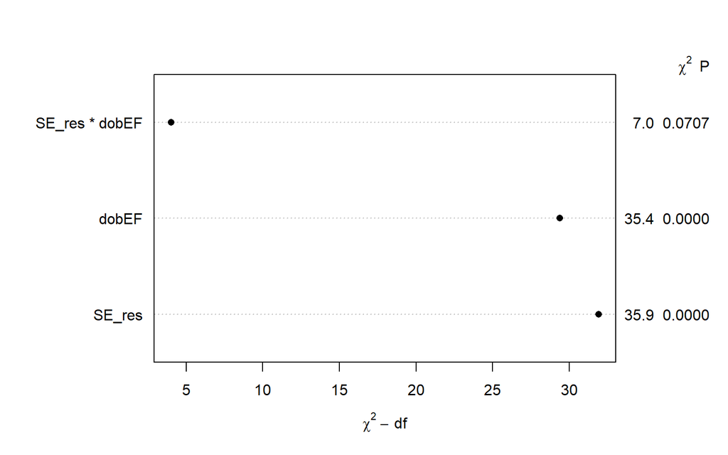

```r
plot(anova(m.2))
```

### 11.2.2 Effects Summary for Model 2

Here is the summary of effects for this model.

```r
summary(m.2)
```

```
             Effects              Response : event

 Factor                     Low High Diff. Effect   S.E.    Lower 0.95
 dobEF                      62  73   11    -0.75299 0.39908 -1.53520
  Odds Ratio                62  73   11     0.47096      NA  0.21542
 SE_res - Positive:Negative  1   2   NA     1.75480 0.35228  1.06440
  Odds Ratio                 1   2   NA     5.78230      NA  2.89900
 Upper 0.95
  0.029198
  1.029600
  2.445300
 11.533000

Adjusted to: SE_res=Negative dobEF=67
```

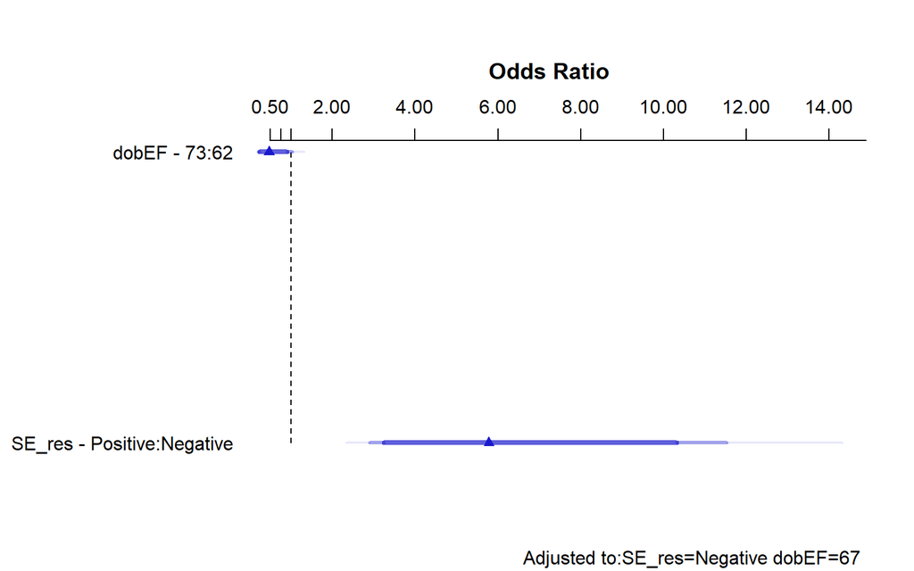

```r
plot(summary(m.2))
```

### 11.2.3 Calibration Plot for Model 2

The calibration plot isn’t great here.

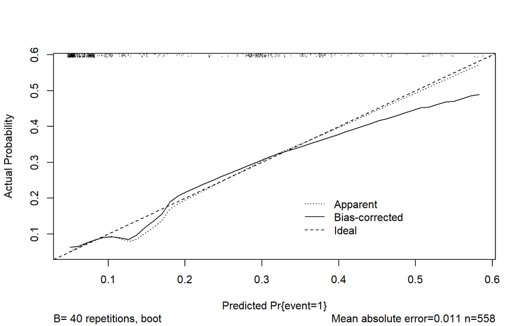

```
n=558   Mean absolute error=0.011   Mean squared error=0.00028
0.9 Quantile of absolute error=0.024
```

```r
plot(calibrate(m.2))
```

### 11.2.4 Nomogram for Model 2

And here is the nomogram.

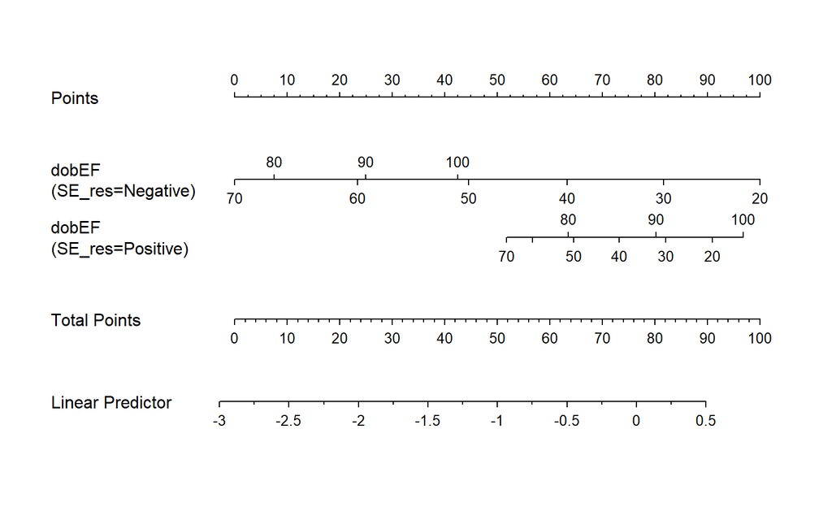

```r
plot(nomogram(m.2))
```

### 11.2.5 Making Predictions with Model 2

Let’s make a mean prediction for two subjects, each with `dobEF = 60` but one with `SE_res` = “Positive” and the other with `SE_res` = “Negative”, using a 90% confidence interval.

```r
Predict(m.2, SE_res = c("Positive", "Negative"), dobEF = 60, conf.int = 0.90)
```

```
    SE_res dobEF      yhat     lower      upper
1 Positive    60 -0.746920 -1.210922 -0.2829182
2 Negative    60 -2.008016 -2.489584 -1.5264480

Response variable (y): log odds

Limits are 0.9 confidence limits
```

It would be more useful if that prediction (and its confidence interval) was on a probability scale…

```r
Predict(m.2, SE_res = c("Positive", "Negative"), dobEF = 60,
        fun = plogis, conf.int = 0.90)
```

```
    SE_res dobEF      yhat      lower     upper
1 Positive    60 0.3214928 0.22953800 0.4297385
2 Negative    60 0.1183639 0.07659163 0.1785140

Response variable (y):

Limits are 0.9 confidence limits
```

### 11.2.6 Plotting Model 2 Predictions

Here is a plot of the predictions across the two levels of `SE_res` for patients with `dobEF` ranging from 60 to 85.

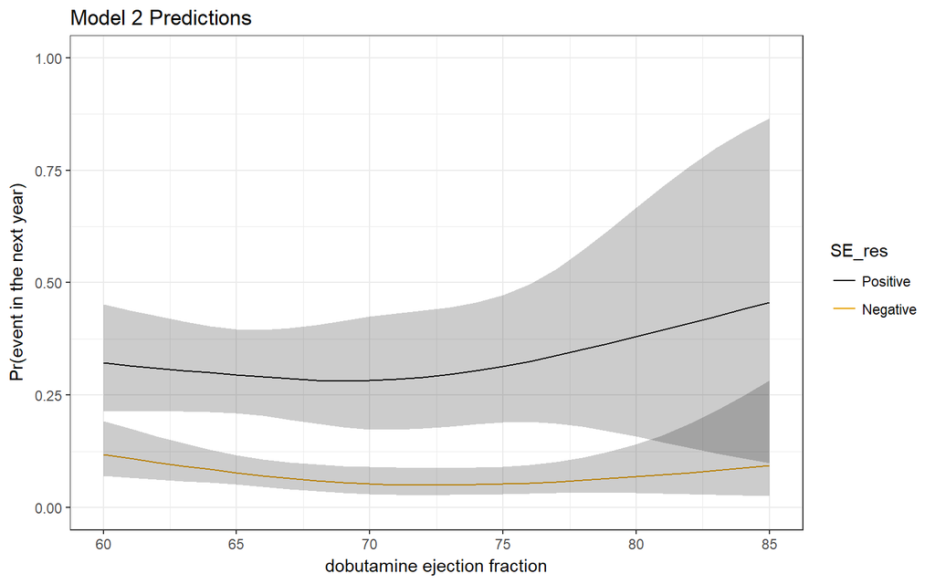

```r
ggplot(Predict(m.2, dobEF = 60:85,
               SE_res = c("Positive", "Negative"), fun=plogis)) +
    theme_bw() +
    labs(x = "dobutamine ejection fraction",
         y = "Pr(event in the next year)",
         title = "Model 2 Predictions")
```

### 11.2.7 Plotting the ROC curve for Model 2

Again, we need to fit Model 2 in `glm`, rather than `rms`.

```r
model.2 <- glm(event ~ SE_res * rcs(dobEF,4), data = stressEcho,
               family = binomial(link = logit))
```

Model 2 has no predictors with missing values, so the next step is relatively straightforward.

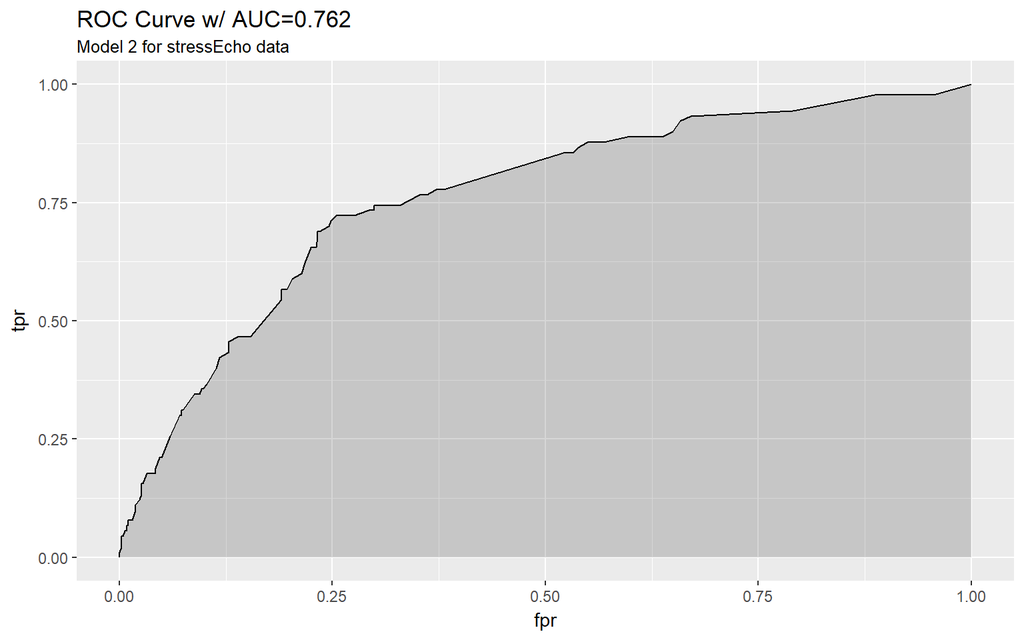

```r
# requires ROCR package
prob <- predict(model.2, data = stressEcho, type="response")
pred <- prediction(prob, stressEcho$event)
# rest of this doesn't need much adjustment except for titles
perf <- performance(pred, measure = "tpr", x.measure = "fpr")
auc <- performance(pred, measure="auc")
auc <- round(auc@y.values[[1]],3)
roc.data <- data.frame(fpr=unlist(perf@x.values),
                       tpr=unlist(perf@y.values),
                       model="GLM")
ggplot(roc.data, aes(x=fpr, ymin=0, ymax=tpr)) +
    geom_ribbon(alpha=0.2) +
    geom_line(aes(y=tpr)) +
    labs(title = paste0("ROC Curve w/ AUC=", auc),
         subtitle = "Model 2 for stressEcho data")
```

## 11.3 Model 3 (with imputation)

Let’s consider a model that includes some variables with missing values, just to see how that works out. We’ll create a model 3 with an interaction for `SE_res` and `dobEF` plus main effects for `baseEF` and `hx_smoking`, since `baseEF` and `hx_smoking` each have a few missing values.

### 11.3.1 Imputation Model

```r
f.3 <- aregImpute(~event + SE_res + dobEF + baseEF + hx_smoking,
                  n.impute = 100, data = stressEcho, pr = FALSE, x = TRUE)
f.3
```

```
Multiple Imputation using Bootstrap and PMM

aregImpute(formula = ~event + SE_res + dobEF + baseEF + hx_smoking,
    data = stressEcho, n.impute = 100, x = TRUE, pr = FALSE)

n: 558  p: 5    Imputations: 100    nk: 3

Number of NAs:
     event     SE_res      dobEF     baseEF hx_smoking
         0          0          0          3          1

           type d.f.
event         l    1
SE_res        c    1
dobEF         s    2
baseEF        s    2
hx_smoking    c    1

Transformation of Target Variables Forced to be Linear

R-squares for Predicting Non-Missing Values for Each Variable
Using Last Imputations of Predictors
    baseEF hx_smoking
     0.810      0.039
```

### 11.3.2 Fitting the Model after Imputation

```r
fmi.m.3 <- fit.mult.impute(event ~ SE_res * dobEF + baseEF + hx_smoking,
                           lrm, f.3, data = stressEcho)
```

```
Variance Inflation Factors Due to Imputation:

              Intercept         SE_res=Positive                   dobEF
                   1.00                    1.00                    1.01
                 baseEF       hx_smoking=smoker SE_res=Positive * dobEF
                   1.01                    1.00                    1.00

Rate of Missing Information:

              Intercept         SE_res=Positive                   dobEF
                   0.00                    0.00                    0.01
                 baseEF       hx_smoking=smoker SE_res=Positive * dobEF
                   0.01                    0.00                    0.00

d.f. for t-distribution for Tests of Single Coefficients:

              Intercept         SE_res=Positive                   dobEF
           427276250964             16775369493                 2799540
                 baseEF       hx_smoking=smoker SE_res=Positive * dobEF
                1566675              5088519018             91794814676

The following fit components were averaged over the 100 model fits:

  stats linear.predictors
```

```r
fmi.m.3
```

```
Logistic Regression Model

 fit.mult.impute(formula = event ~ SE_res * dobEF + baseEF + hx_smoking,
     fitter = lrm, xtrans = f.3, data = stressEcho)

                       Model Likelihood     Discrimination    Rank Discrim.
                          Ratio Test           Indexes           Indexes
 Obs           558    LR chi2      69.49    R2       0.200    C       0.754
  0            468    d.f.             5    g        1.121    Dxy     0.509
  1             90    Pr(> chi2) <0.0001    gr       3.068    gamma   0.510
 max |deriv| 1e-10                          gp       0.141    tau-a   0.138
                                            Brier    0.116

                         Coef    S.E.   Wald Z Pr(>|Z|)
 Intercept                2.0157 0.8298  2.43  0.0151
 SE_res=Positive         -1.4233 1.1563 -1.23  0.2184
 dobEF                   -0.0756 0.0258 -2.93  0.0034
 baseEF                   0.0107 0.0261  0.41  0.6815
 hx_smoking=smoker        0.0377 0.2514  0.15  0.8808
 SE_res=Positive * dobEF  0.0455 0.0188  2.42  0.0154
```

### 11.3.3 ANOVA plot after imputation

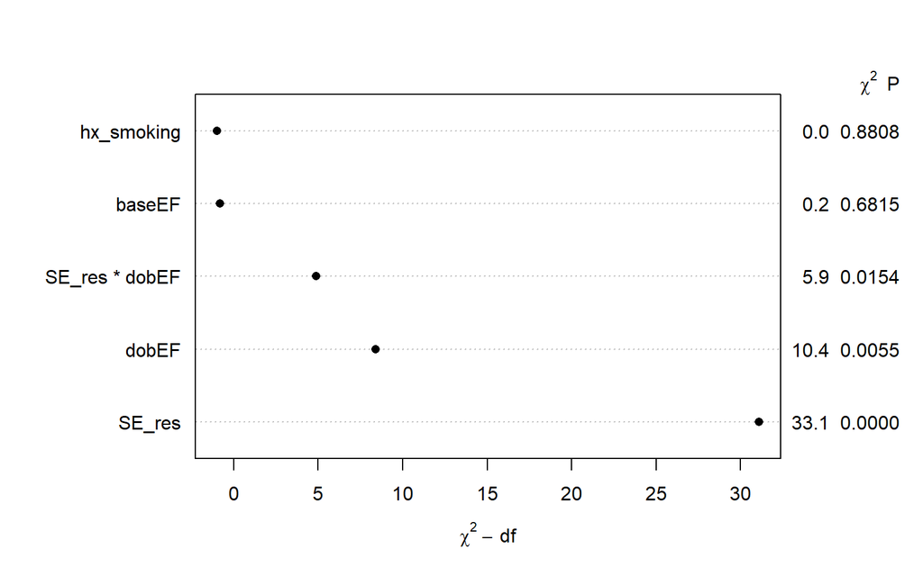

```r
plot(anova(fmi.m.3))
```

### 11.3.4 Effects plot after imputation

```r
summary(fmi.m.3)
```

```
             Effects              Response : event

 Factor                         Low High Diff. Effect    S.E.
 dobEF                          62  73   11    -0.831460 0.28421
  Odds Ratio                    62  73   11     0.435410      NA
 baseEF                         52  62   10     0.107230 0.26127
  Odds Ratio                    52  62   10     1.113200      NA
 SE_res - Positive:Negative      1   2   NA     1.622800 0.28231
  Odds Ratio                     1   2   NA     5.067200      NA
 hx_smoking - smoker:non-smoker  1   2   NA     0.037687 0.25142
  Odds Ratio                     1   2   NA     1.038400      NA
 Lower 0.95 Upper 0.95
 -1.38850   -0.27442
  0.24945    0.76001
 -0.40485    0.61930
  0.66708    1.85760
  1.06950    2.17610
  2.91380    8.81180
 -0.45509    0.53046
  0.63439    1.69970

Adjusted to: SE_res=Negative dobEF=67
```

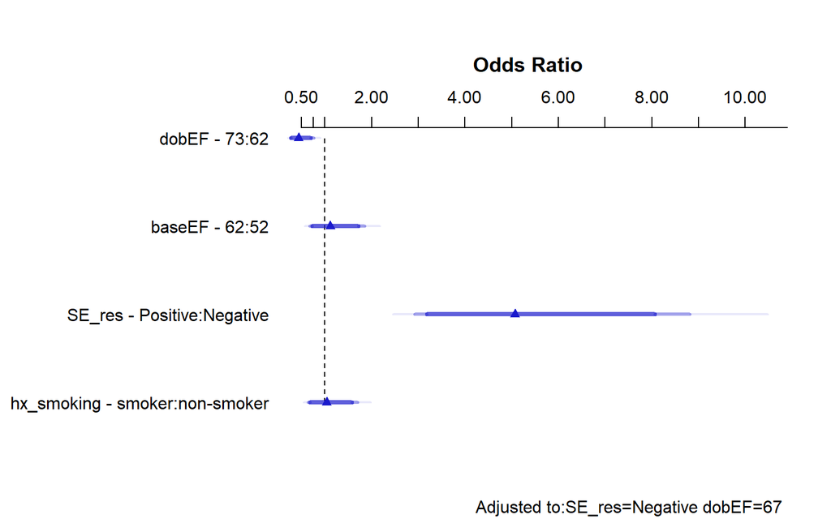

```r
plot(summary(fmi.m.3))
```

### 11.3.5 Nomogram after imputation

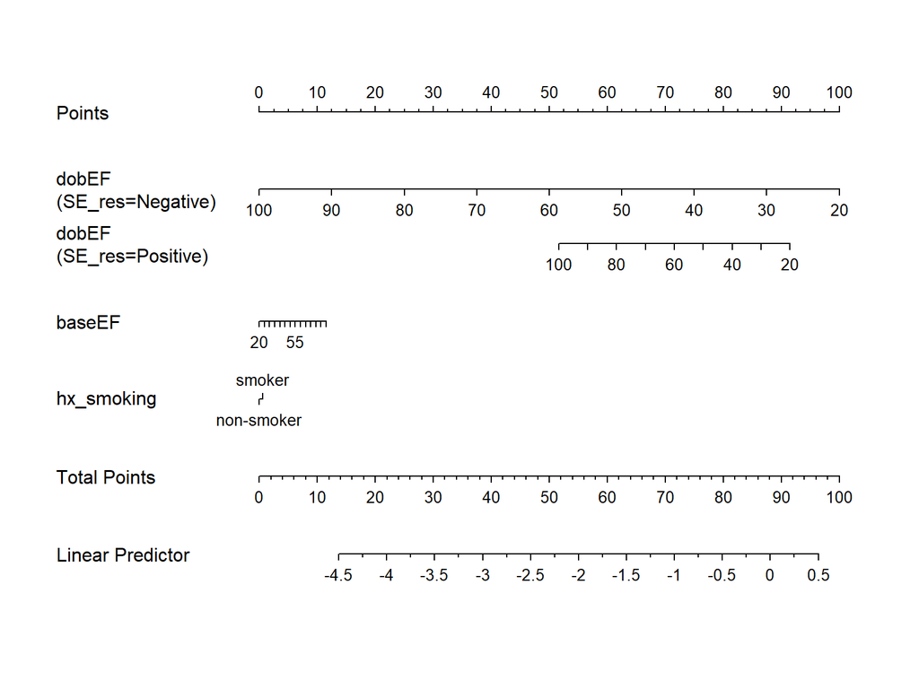

```r
plot(nomogram(fmi.m.3))
```

Note that the `Predict`, `validate` and `calibrate` ideas don’t play well with `fit.mult.impute`, so we won’t address those here. If we wanted to address those issues for Model 3, we would simply refit the model using only the complete cases, or do a simple imputation and then run them.

# 12 Endnotes

[^1]: The four cardiac outcomes under study are death, myocardial infarction, percutaneous transluminal coronary angioplasty (PTCA), and coronary artery bypass graft surgery (CABG) and whether any of these occurred in the 12 months following dobutamine stress echocardiography.
[^2]: I know this because I’ve spent some time analyzing these data in the past. Note that some other versions of these data produce 89 patients with events, and not 90, including the version at the Vanderbilt Biostatistics wiki, but this derived `event` variable is what we’ll go with.
[^3]: Ejection fraction is a measure of the heart’s pumping efficiency.
[^4]: The `MI` category in `ecg` means that the electrocardiogram showed signs of a heart attack.

Thomas E. Love for 432

2018-02-07 12:08:35